# Titanic

## Import data

```python
# we have to restart runtime
!pip install lazypredict
```

```python
# Import the data from Kaggle API
!pip install kaggle
import os
os.environ['KAGGLE_USERNAME'] = "bensaidlucas" # username from the json file
os.environ['KAGGLE_KEY'] = "e66b7ce0f4e8abb888db31a380aeb61d" # key from the json file
! kaggle competitions download -c titanic
```

```python
# Scikit-learn packages
from sklearn.ensemble import GradientBoostingRegressor
from sklearn.preprocessing import OneHotEncoder, StandardScaler, FunctionTransformer
from sklearn.model_selection import train_test_split, GridSearchCV, cross_val_score
from sklearn.metrics import mean_squared_error, classification_report, accuracy_score

# import models
from lightgbm import LGBMClassifier
from sklearn.linear_model import LogisticRegression
import xgboost
from sklearn.ensemble import AdaBoostClassifier, RandomForestClassifier
from sklearn.svm import SVC
from sklearn.neighbors import KNeighborsClassifier
from sklearn.tree import DecisionTreeClassifier

# Hide warnings
import warnings
warnings.filterwarnings("ignore")

# Lazy Predict packages
from lazypredict.Supervised import LazyRegressor,LazyClassifier

import pandas as pd
import matplotlib.pyplot as plt
import numpy as np
import seaborn as sns


# Setting up max columns displayed to 100
pd.options.display.max_columns = 10
```

```python
# Our datasets
df_train = pd.read_csv('/content/train.csv')
df_test = pd.read_csv('/content/test.csv')

dfs = [('train',df_train), ('test',df_test)]
df_full = pd.concat([df_train, df_test], axis = 0).reset_index(drop=True)
```

## EDA

### Datasets

```python
for df in dfs:
  print(df[0],':\n')
  print(df[1].info(),'\n\n\n')
```

```
train :

<class 'pandas.core.frame.DataFrame'>
RangeIndex: 891 entries, 0 to 890
Data columns (total 12 columns):
 #   Column       Non-Null Count  Dtype
---  ------       --------------  -----
 0   PassengerId  891 non-null    int64
 1   Survived     891 non-null    int64
 2   Pclass       891 non-null    int64
 3   Name         891 non-null    object
 4   Sex          891 non-null    object
 5   Age          714 non-null    float64
 6   SibSp        891 non-null    int64
 7   Parch        891 non-null    int64
 8   Ticket       891 non-null    object
 9   Fare         891 non-null    float64
 10  Cabin        204 non-null    object
 11  Embarked     889 non-null    object
dtypes: float64(2), int64(5), object(5)
memory usage: 83.7+ KB
None



test :

<class 'pandas.core.frame.DataFrame'>
RangeIndex: 418 entries, 0 to 417
Data columns (total 11 columns):
 #   Column       Non-Null Count  Dtype
---  ------       --------------  -----
 0   PassengerId  418 non-null    int64
 1   Pclass       418 non-null    int64
 2   Name         418 non-null    object
 3   Sex          418 non-null    object
 4   Age          332 non-null    float64
 5   SibSp        418 non-null    int64
 6   Parch        418 non-null    int64
 7   Ticket       418 non-null    object
 8   Fare         417 non-null    float64
 9   Cabin        91 non-null     object
 10  Embarked     418 non-null    object
dtypes: float64(2), int64(4), object(5)
memory usage: 36.0+ KB
None
```

```python
df_train.head()
```

|  | PassengerId | Survived | Pclass | Name | Sex | ... | Parch | Ticket | Fare | Cabin | Embarked |
| --- | --- | --- | --- | --- | --- | --- | --- | --- | --- | --- | --- |
| 0 | 1 | 0 | 3 | Braund, Mr. Owen Harris | male | ... | 0 | A/5 21171 | 7.25 | NaN | S |
| 1 | 2 | 1 | 1 | Cumings, Mrs. John Bradley (Florence Briggs Th... | female | ... | 0 | PC 17599 | 71.28 | C85 | C |
| 2 | 3 | 1 | 3 | Heikkinen, Miss. Laina | female | ... | 0 | STON/O2. 3101282 | 7.92 | NaN | S |
| 3 | 4 | 1 | 1 | Futrelle, Mrs. Jacques Heath (Lily May Peel) | female | ... | 0 | 113803 | 53.10 | C123 | S |
| 4 | 5 | 0 | 3 | Allen, Mr. William Henry | male | ... | 0 | 373450 | 8.05 | NaN | S |

5 rows × 12 columns

### Nan Values

```python
# Count / percentage of Nan values per columns
for df in dfs:
  pr = pd.Series(df[1].isna().sum() / len(df[1]), name='percent')
  nb = pd.Series(df[1].isna().sum(), name='count')

  print(df[0],':\n')

  display(pd.concat([nb, pr],axis =1))
  print('\n\n')
```

```
train :
```

|  | count | percent |
| --- | --- | --- |
| PassengerId | 0 | 0.00 |
| Survived | 0 | 0.00 |
| Pclass | 0 | 0.00 |
| Name | 0 | 0.00 |
| Sex | 0 | 0.00 |
| Age | 177 | 0.20 |
| SibSp | 0 | 0.00 |
| Parch | 0 | 0.00 |
| Ticket | 0 | 0.00 |
| Fare | 0 | 0.00 |
| Cabin | 687 | 0.77 |
| Embarked | 2 | 0.00 |

```
test :
```

|  | count | percent |
| --- | --- | --- |
| PassengerId | 0 | 0.00 |
| Pclass | 0 | 0.00 |
| Name | 0 | 0.00 |
| Sex | 0 | 0.00 |
| Age | 86 | 0.21 |
| SibSp | 0 | 0.00 |
| Parch | 0 | 0.00 |
| Ticket | 0 | 0.00 |
| Fare | 1 | 0.00 |
| Cabin | 327 | 0.78 |
| Embarked | 0 | 0.00 |

**Cabin** has more than 75% values in both datasets we will drop it

```python
for df in dfs:
  df[1].drop('Cabin', axis = 1, inplace =True)
```

**Embarked** from train

From [link](https://www.encyclopedia-titanica.org/titanic-survivor/martha-evelyn-stone.html):

> "*Mrs Stone boarded the Titanic in Southampton on 10 April 1912 and was travelling in first class with her maid Amelie Icard. She occupied cabin B-28.*"

We will fill by 'S'

```python
df_train.loc[df_train['Embarked'].isnull()]
```

|  | PassengerId | Survived | Pclass | Name | Sex | ... | SibSp | Parch | Ticket | Fare | Embarked |
| --- | --- | --- | --- | --- | --- | --- | --- | --- | --- | --- | --- |
| 61 | 62 | 1 | 1 | Icard, Miss. Amelie | female | ... | 0 | 0 | 113572 | 80.00 | NaN |
| 829 | 830 | 1 | 1 | Stone, Mrs. George Nelson (Martha Evelyn) | female | ... | 0 | 0 | 113572 | 80.00 | NaN |

2 rows × 11 columns

```python
df_train.loc[df_train['Embarked'].isnull(), 'Embarked'] = 'S'
```

Next:

**Train**:

> Fill nan values of Age

**Test**:

> Fill nan values of Age and Fare

### Data types

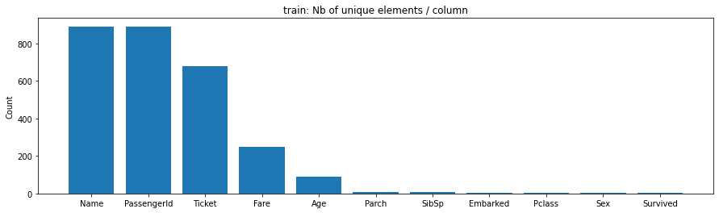

```
Unique element / column:
```

|  | number | percentage |
| --- | --- | --- |
| Name | 891 | 1.00 |
| PassengerId | 891 | 1.00 |
| Ticket | 681 | 0.76 |
| Fare | 248 | 0.28 |
| Age | 88 | 0.10 |
| Parch | 7 | 0.01 |
| SibSp | 7 | 0.01 |
| Embarked | 3 | 0.00 |
| Pclass | 3 | 0.00 |
| Sex | 2 | 0.00 |
| Survived | 2 | 0.00 |

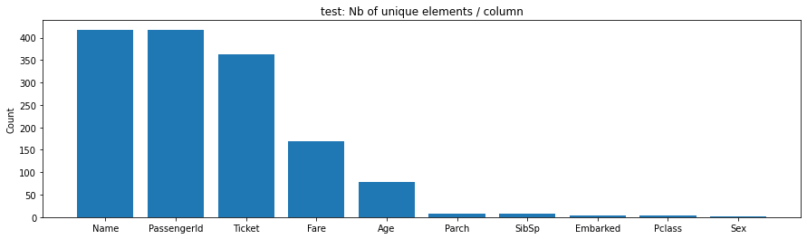

```
Unique element / column:
```

|  | number | percentage |
| --- | --- | --- |
| Name | 418 | 1.00 |
| PassengerId | 418 | 1.00 |
| Ticket | 363 | 0.87 |
| Fare | 169 | 0.40 |
| Age | 79 | 0.19 |
| Parch | 8 | 0.02 |
| SibSp | 7 | 0.02 |
| Embarked | 3 | 0.01 |
| Pclass | 3 | 0.01 |
| Sex | 2 | 0.00 |

```python
for df in dfs:

  t = df[1].nunique().sort_values(ascending=False)

  plt.figure(figsize=(15,4))
  plt.title(f"{df[0]}: Nb of unique elements / column")
  plt.ylabel('Count')
  plt.bar(t.index, t.values)
  plt.show()

  nb = pd.Series(t, name = 'number')
  pr = pd.Series(t/len(df[1]), name = 'percentage')

  print('\n\nUnique element / column:')
  display(pd.concat([nb,pr], axis=1))
  print('\n\n')
```

**Numerical:**

- Discrete

  > Parch, SibSp
- Continuous

  > Fare, Age

**Categorical:**

- Nominal

  > Name, PassengerId, Ticket, Cabin, Embarked, Sex, Survived (*target*)
- Ordinal

  > Pclass

```python
num_cols = ['Fare', 'Age']
num_cnt_cols = ['Parch', 'SibSp']
nominal_cols = ['Name', 'PassengerId', 'Ticket', 'Embarked', 'Sex']
ordinal_cols = ['Pclass']
target = ['Survived']
```

### Data distribution

#### Target

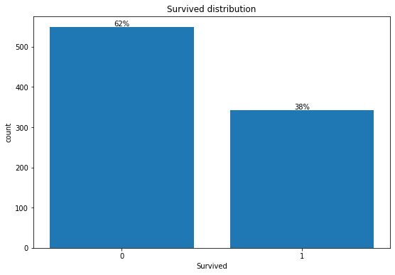

```python
t = df_train['Survived'].value_counts(sort=False)

plt.figure(figsize=(9,6))
plt.bar(t.index.astype('str'), t)
plt.ylabel('count')
plt.xlabel('Survived')
plt.title('Survived distribution')


for i in t.index:
  plt.annotate("{0:.0f}%".format(t[i]*100/len(df_train)),xy=(i, t[i]) ,ha='center', va='bottom')
plt.show()
```

38 % of the passenger survived

#### Numerical

##### Distribution

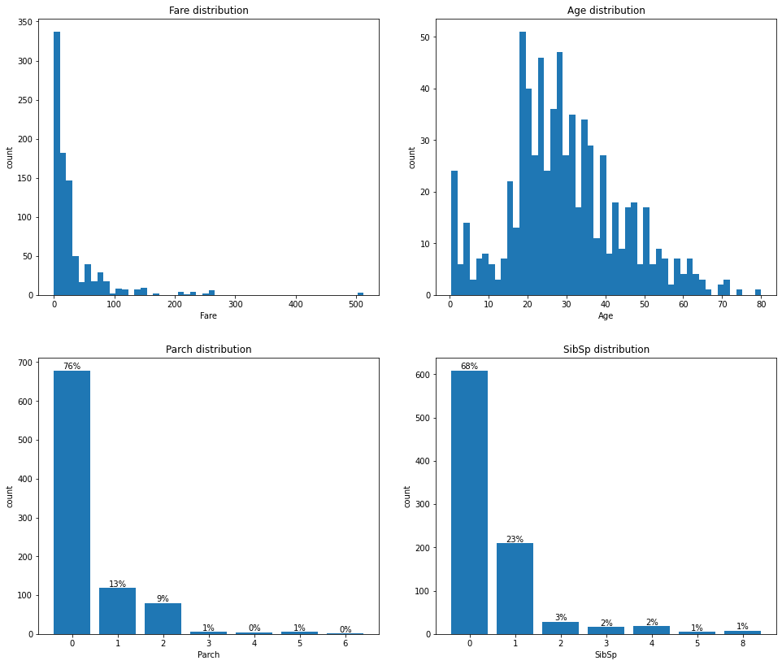

```python
plt.figure(figsize=(14,12))
i=1
for col in num_cols:
  plt.subplot(2,2,i)
  plt.hist(df_train[col], bins=50)
  plt.ylabel('count')
  plt.xlabel(col)
  plt.title(col+' distribution')
  i+=1

for col in num_cnt_cols:
  plt.subplot(2,2,i)
  vc = df_train[col].value_counts(sort=False)

  plt.bar(vc.index.astype(str), vc)
  plt.ylabel('count')
  plt.xlabel(col)
  plt.title(col+' distribution')

  for id in vc.index:
    plt.annotate("{0:.0f}%".format(vc[id]*100/len(df_train)),xy=(str(id), vc[id]) ,ha='center', va='bottom')

  i+=1

plt.tight_layout(pad=3)
plt.show()
```

```python
df_train[num_cols + num_cnt_cols].describe()
```

|  | Fare | Age | Parch | SibSp |
| --- | --- | --- | --- | --- |
| count | 891.00 | 714.00 | 891.00 | 891.00 |
| mean | 32.20 | 29.70 | 0.38 | 0.52 |
| std | 49.69 | 14.53 | 0.81 | 1.10 |
| min | 0.00 | 0.42 | 0.00 | 0.00 |
| 25% | 7.91 | 20.12 | 0.00 | 0.00 |
| 50% | 14.45 | 28.00 | 0.00 | 0.00 |
| 75% | 31.00 | 38.00 | 0.00 | 1.00 |
| max | 512.33 | 80.00 | 6.00 | 8.00 |

Most of passengers have 0 PARentsCHildren and 0 SIBlingSPouse => Alone

The average Age is around 30 years

##### Distribution / target

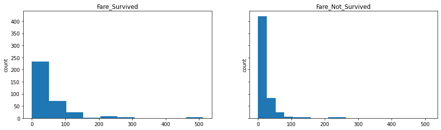

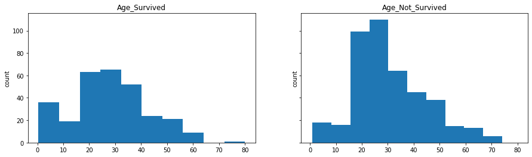

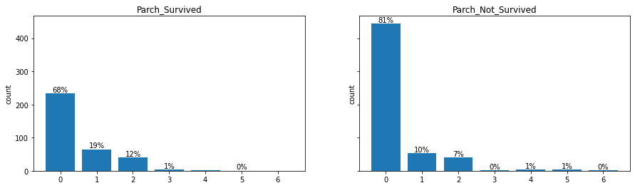

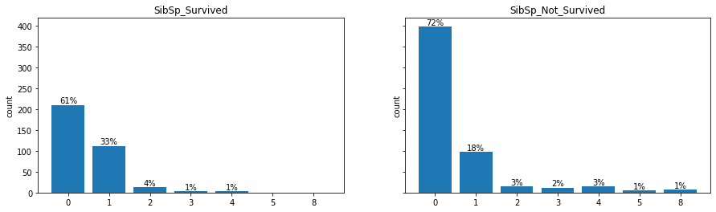

```python
for col in num_cols:
  i=0
  f, sub = plt.subplots(1,2,figsize=(15,4) ,sharex=True, sharey=True)
  sub[i].hist(df_train[col].loc[df_train['Survived']==1])
  sub[i].set_ylabel('count')
  sub[i].set_title(col+'_Survived')
  i+=1
  sub[i].hist(df_train[col].loc[df_train['Survived']==0])
  sub[i].set_ylabel('count')
  sub[i].set_title(col+'_Not_Survived')
  i+=1


for col in num_cnt_cols:
  i=0
  f, sub = plt.subplots(1,2,figsize=(15,4) , sharex=True, sharey=True)
  vc = df_train[col].loc[df_train['Survived']==1].value_counts(sort=False)
  sub[i].bar(vc.index.astype(str),vc)
  sub[i].set_ylabel('count')
  sub[i].set_title(col+'_Survived')

  for id in vc.index:
    sub[i].annotate("{0:.0f}%".format(vc[id]*100/sum(vc)),xy=(id, vc[id]) ,ha='center', va='bottom')

  i+=1

  vc = df_train[col].loc[df_train['Survived']==0].value_counts(sort=False)
  sub[i].bar(vc.index.astype(str),vc)
  sub[i].set_ylabel('count')
  sub[i].set_title(col+'_Not_Survived')

  for id in vc.index:
    sub[i].annotate("{0:.0f}%".format(vc[id]*100/sum(vc)),xy=(str(id), vc[id]) ,ha='center', va='bottom')

  i+=1

plt.show()
```

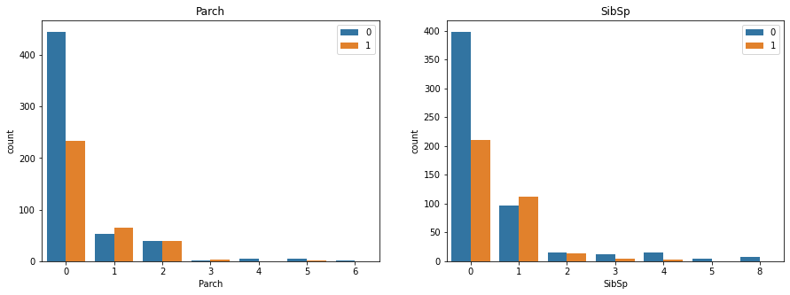

```python
f,sub=plt.subplots(1,2,figsize=(15, 5))
i=0

for col in num_cnt_cols:
  sns.countplot(ax=sub[i], x= col, data = df_train, hue = 'Survived')
  sub[i].legend(loc='upper right')
  sub[i].set_title(col)
  i+=1
```

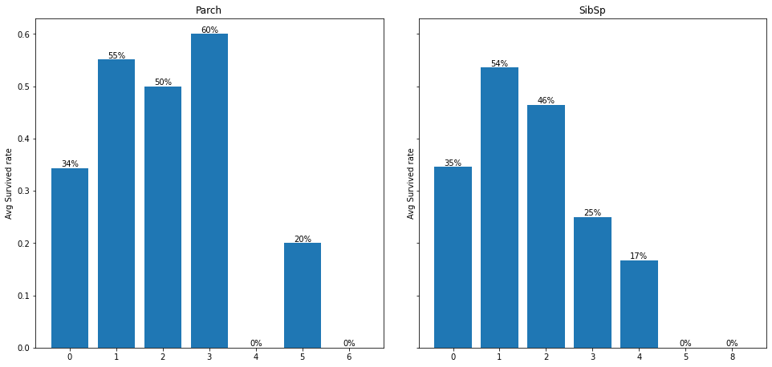

```python
f,sub = plt.subplots(1,2, figsize=(14,7) ,sharey=True)
i=0
for col in num_cnt_cols:
  gp = df_train.groupby([col]).Survived.mean()
  sub[i].bar(gp.index.astype(str), gp)
  sub[i].set_ylabel('Avg Survived rate')
  sub[i].set_title(col)
  for id in gp.index:
    sub[i].annotate("{0:.0f}%".format(gp[id]*100),xy=(str(id), gp[id])
    ,ha='center', va='bottom')

  i+=1

plt.tight_layout(pad=3)
plt.show()
```

#### Nominal

##### Overview

```python
df_train[nominal_cols].describe(include='O')
```

|  | Name | Ticket | Embarked | Sex |
| --- | --- | --- | --- | --- |
| count | 891 | 891 | 891 | 891 |
| unique | 891 | 681 | 3 | 2 |
| top | Thorneycroft, Mrs. Percival (Florence Kate White) | 1601 | S | male |
| freq | 1 | 7 | 646 | 577 |

```python
df_train[['Name','Ticket']].head()
```

|  | Name | Ticket |
| --- | --- | --- |
| 0 | Braund, Mr. Owen Harris | A/5 21171 |
| 1 | Cumings, Mrs. John Bradley (Florence Briggs Th... | PC 17599 |
| 2 | Heikkinen, Miss. Laina | STON/O2. 3101282 |
| 3 | Futrelle, Mrs. Jacques Heath (Lily May Peel) | 113803 |
| 4 | Allen, Mr. William Henry | 373450 |

From the name we can extract the title

##### Distribution

```python
df_train[nominal_cols].describe(include='O')
```

|  | Name | Ticket | Embarked | Sex |
| --- | --- | --- | --- | --- |
| count | 891 | 891 | 891 | 891 |
| unique | 891 | 681 | 3 | 2 |
| top | Thorneycroft, Mrs. Percival (Florence Kate White) | 1601 | S | male |
| freq | 1 | 7 | 646 | 577 |

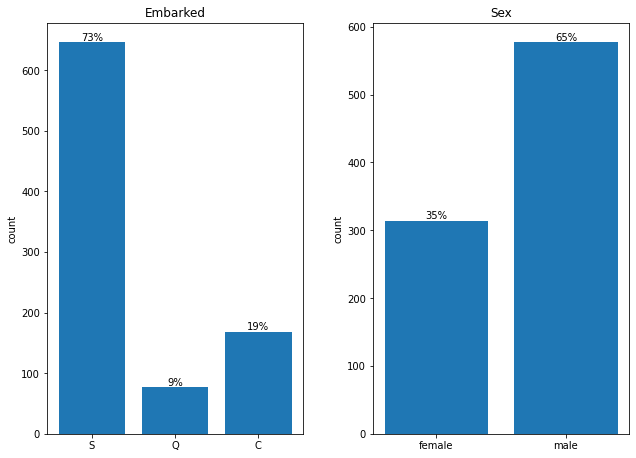

```python
t = df_train[nominal_cols].nunique()<10

plt.figure(figsize=(14,7))
i=1
for col in t[t].index:
  plt.subplot(1,3,i)
  vc = df_train[col].value_counts(sort=False)

  plt.bar(vc.index, vc)
  plt.ylabel('count')
  plt.title(col)

  for id in vc.index:
    plt.annotate("{0:.0f}%".format(vc[id]*100/len(df_train)),xy=(id, vc[id]) ,ha='center', va='bottom')

  i+=1
plt.tight_layout(pad=3)
plt.show()
```

##### Distribution / target

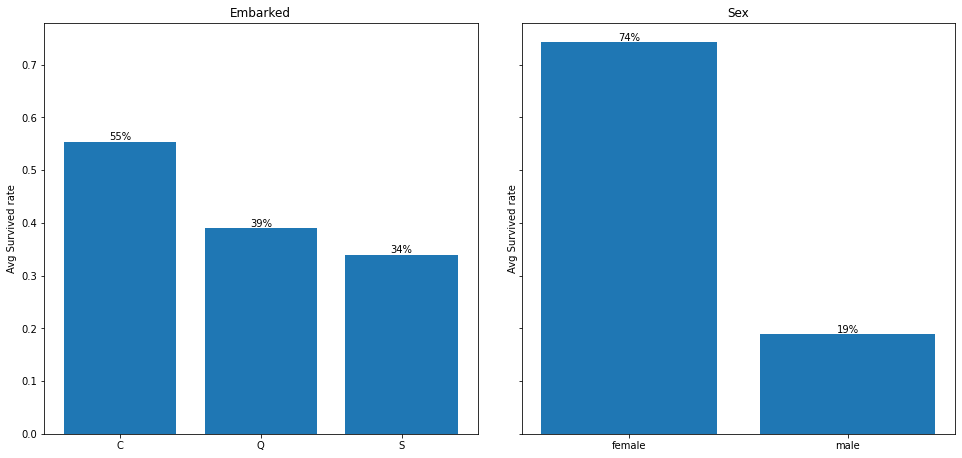

```python
f, sub = plt.subplots(1,2, figsize=(14,7), sharey = True)
i=0
for col in t[t].index:
  gp = df_train.groupby([col]).Survived.mean()
  sub[i].bar(gp.index, gp)
  sub[i].set_ylabel('Avg Survived rate')
  sub[i].set_title(col)
  for id in gp.index:
    sub[i].annotate("{0:.0f}%".format(gp[id]*100),xy=(id, gp[id])
    ,ha='center', va='bottom')
  i+=1
plt.tight_layout(pad=3)
plt.show()
```

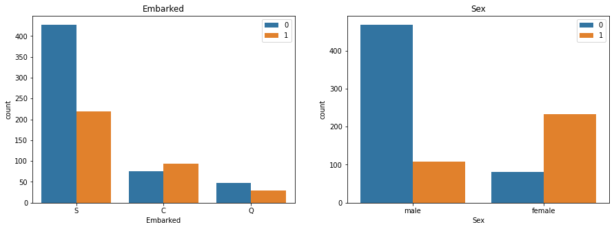

```python
f,sub=plt.subplots(1,2,figsize=(15, 5))
i=0

for col in t[t].index:
  sns.countplot(ax=sub[i], x= col, data = df_train, hue = 'Survived')
  sub[i].legend(loc='upper right')
  sub[i].set_title(col)
  i+=1
```

Observations:

- Male passengers have a terrible survival rate (80% died) and female a great one (74% survived)
- Passengers have embarked from C have higher survival rate (55%) much better than passengers from S (34%) it may be related to the class

#### Ordinal

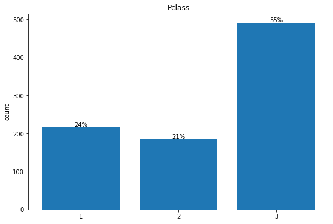

```python
t = df_train['Pclass'].value_counts(sort=False)

plt.figure(figsize=(9,6))
plt.bar(t.index.astype('str'), t.values)
plt.ylabel('count')
plt.title('Pclass')

for id in t.index:
  plt.annotate("{0:.0f}%".format(t[id]*100/sum(t)),xy=(str(id), t[id]) ,ha='center', va='bottom')
plt.show()
```

##### Distribution / target

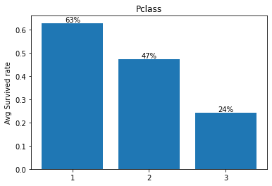

```python
col='Pclass'
gp = df_train.groupby([col]).Survived.mean()
plt.bar(gp.index.astype(str), gp)
plt.ylabel('Avg Survived rate')
plt.title(col)
for id in gp.index:
  plt.annotate("{0:.0f}%".format(gp[id]*100),xy=(str(id), gp[id])
  ,ha='center', va='bottom')
plt.show()
```

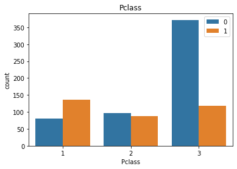

```python
sns.countplot(x= col, data = df_train, hue = 'Survived')
plt.legend(loc='upper right')
plt.title(col)
plt.show()
```

Observations:

## Feature engineering 1

Title / Familly / Alone / Connected Survival

#### Title

```python
for df in dfs:
  df[1]['Title'] = df[1]['Name'].str.extract('([A-Za-z]+)\.', expand=False)
  print(df[0],':')
  display(pd.crosstab(df[1]['Title'], df[1]['Sex']))
  print('\n\n')
```

```
train :
```

| Sex Title | female | male |
| --- | --- | --- |
| Capt | 0 | 1 |
| Col | 0 | 2 |
| Countess | 1 | 0 |
| Don | 0 | 1 |
| Dr | 1 | 6 |
| Jonkheer | 0 | 1 |
| Lady | 1 | 0 |
| Major | 0 | 2 |
| Master | 0 | 40 |
| Miss | 182 | 0 |
| Mlle | 2 | 0 |
| Mme | 1 | 0 |
| Mr | 0 | 517 |
| Mrs | 125 | 0 |
| Ms | 1 | 0 |
| Rev | 0 | 6 |
| Sir | 0 | 1 |

```
test :
```

| Sex Title | female | male |
| --- | --- | --- |
| Col | 0 | 2 |
| Dona | 1 | 0 |
| Dr | 0 | 1 |
| Master | 0 | 21 |
| Miss | 78 | 0 |
| Mr | 0 | 240 |
| Mrs | 72 | 0 |
| Ms | 1 | 0 |
| Rev | 0 | 2 |

```python
for df in dfs:
  df[1]['Title'] = df[1]['Title'].replace(['Lady', 'Countess','Capt', 'Col',\
  'Don', 'Dr', 'Major', 'Rev', 'Sir', 'Jonkheer', 'Dona'], 'High')
  df[1]['Title'] = df[1]['Title'].replace('Mlle', 'Miss')
  df[1]['Title'] = df[1]['Title'].replace('Ms', 'Miss')
  df[1]['Title'] = df[1]['Title'].replace('Mme', 'Mrs')
```

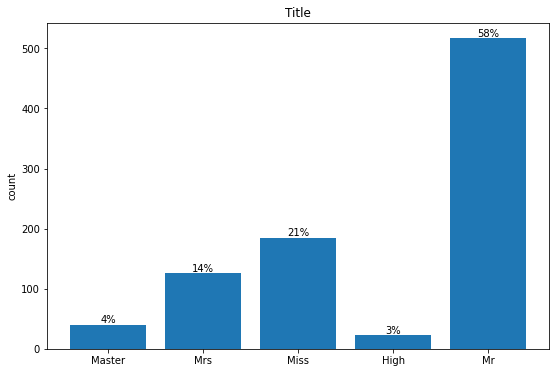

```python
t = df_train['Title'].value_counts(sort=False)

plt.figure(figsize=(9,6))
plt.bar(t.index.astype('str'), t.values)
plt.ylabel('count')
plt.title('Title')

for id in t.index:
  plt.annotate("{0:.0f}%".format(t[id]*100/sum(t)),xy=(str(id), t[id]) ,ha='center', va='bottom')
plt.show()
```

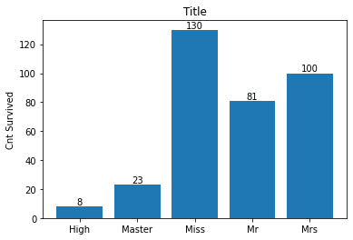

```python
gp = df_train.groupby(['Title']).Survived.sum()
plt.bar(gp.index, gp)
plt.ylabel('Cnt Survived')
plt.title('Title')

for id in gp.index:
  plt.annotate("{0:.0f}".format(gp[id]),xy=(id, gp[id])
  ,ha='center', va='bottom')
```

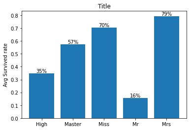

```python
gp = df_train.groupby(['Title']).Survived.mean()
plt.bar(gp.index, gp)
plt.ylabel('Avg Survived rate')
plt.title('Title')

for id in gp.index:
  plt.annotate("{0:.0f}%".format(gp[id]*100),xy=(id, gp[id])
  ,ha='center', va='bottom')
```

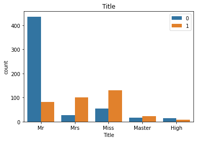

```python
col='Title'
sns.countplot(x= col, data = df_train, hue = 'Survived')
plt.legend(loc='upper right')
plt.title(col)
plt.show()
```

```python
nominal_cols.append('Title')
```

Observations:

- Validating our previous observation female (Mrs, Miss) have much higher survival rate than male (Mr).
- Hight & Master title have higher survival rate than Mr and a lower than female (Mrs, Miss)

#### Familly

```python
# error this passenger traveled alone
df_train.loc[273, 'Parch'] = 0
```

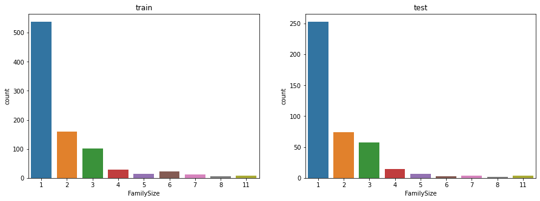

```python
f,sub=plt.subplots(1,2,figsize=(15, 5))
i=0

for df in dfs:
  df[1]['FamilySize'] = df[1]['SibSp'] + df[1]['Parch'] +1
  sns.countplot(ax=sub[i], x= 'FamilySize',data =df[1])
  sub[i].set_title(df[0])
  i+=1
```

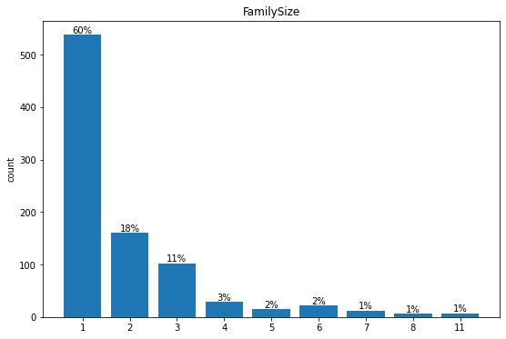

```python
t = df_train['FamilySize'].value_counts(sort=False)

plt.figure(figsize=(9,6))
plt.bar(t.index.astype('str'), t.values)
plt.ylabel('count')
plt.title('FamilySize')

for id in t.index:
  plt.annotate("{0:.0f}%".format(t[id]*100/sum(t)),xy=(str(id), t[id]) ,ha='center', va='bottom')
plt.show()
```

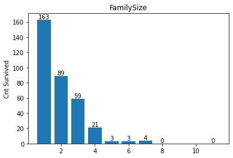

```python
gp = df_train.groupby(['FamilySize']).Survived.sum()
plt.bar(gp.index, gp)
plt.ylabel('Cnt Survived')
plt.title('FamilySize')

for id in gp.index:
  plt.annotate("{0:.0f}".format(gp[id]),xy=(id, gp[id])
  ,ha='center', va='bottom')
```

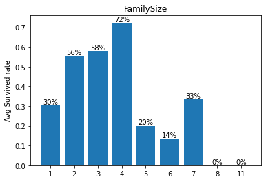

```python
gp = df_train.groupby(['FamilySize']).Survived.mean()
plt.bar(gp.index.astype('str'), gp)
plt.ylabel('Avg Survived rate')
plt.title('FamilySize')

for id in gp.index:
  plt.annotate("{0:.0f}%".format(gp[id]*100),xy=(str(id), gp[id])
  ,ha='center', va='bottom')
```

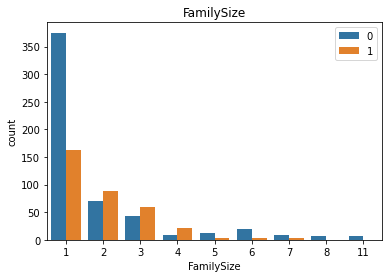

```python
col='FamilySize'
sns.countplot(x= col, data = df_train, hue = 'Survived')
plt.legend(loc='upper right')
plt.title(col)
plt.show()
```

Observations:

- The survival rate increase with the familly size until 4 and decrease after

#### Alone

```
train :
```

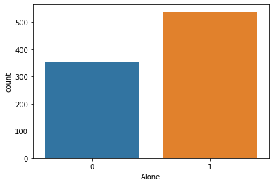

```
test :
```

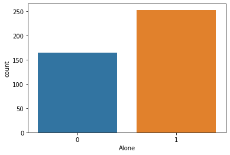

```python
for df in dfs:
  df[1]['Alone'] = 0
  df[1].loc[df[1]['FamilySize']==1, 'Alone' ] = 1
  print(df[0],':')
  sns.countplot(df[1]['Alone'])
  plt.show()
  print('\n\n')
```

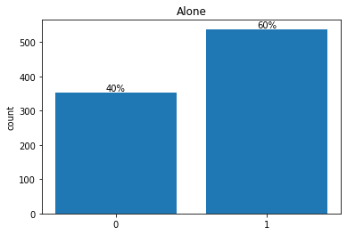

```python
t = df_train['Alone'].value_counts(sort=False)

plt.figure(figsize=(6,4))
plt.bar(t.index.astype('str'), t.values)
plt.ylabel('count')
plt.title('Alone')

for id in t.index:
  plt.annotate("{0:.0f}%".format(t[id]*100/sum(t)),xy=(str(id), t[id]) ,ha='center', va='bottom')
plt.show()
```

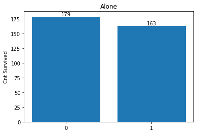

```python
gp = df_train.groupby(['Alone']).Survived.sum()
plt.bar(gp.index.astype('str'), gp)
plt.ylabel('Cnt Survived')
plt.title('Alone')

for id in gp.index:
  plt.annotate("{0:.0f}".format(gp[id]),xy=(str(id), gp[id])
  ,ha='center', va='bottom')
```

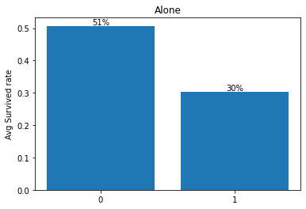

```python
gp = df_train.groupby(['Alone']).Survived.mean()
plt.bar(gp.index.astype('str'), gp)
plt.ylabel('Avg Survived rate')
plt.title('Alone')

for id in gp.index:
  plt.annotate("{0:.0f}%".format(gp[id]*100),xy=(str(id), gp[id])
  ,ha='center', va='bottom')
```

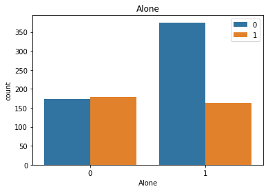

```python
col='Alone'
sns.countplot(x= col, data = df_train, hue = 'Survived')
plt.legend(loc='upper right')
plt.title(col)
plt.show()
```

Observations:

- The survival rate is lower for alone passenger

#### Last Name

```python
for df in dfs:
  df[1]['Last_Name'] = df[1]['Name'].apply(lambda x: str.split(x, ",")[0])
```

```python
df_train.sort_values('Name').head(10)
```

|  | PassengerId | Survived | Pclass | Name | Sex | ... | Embarked | Title | FamilySize | Alone | Last_Name |
| --- | --- | --- | --- | --- | --- | --- | --- | --- | --- | --- | --- |
| 845 | 846 | 0 | 3 | Abbing, Mr. Anthony | male | ... | S | Mr | 1 | 1 | Abbing |
| 746 | 747 | 0 | 3 | Abbott, Mr. Rossmore Edward | male | ... | S | Mr | 3 | 0 | Abbott |
| 279 | 280 | 1 | 3 | Abbott, Mrs. Stanton (Rosa Hunt) | female | ... | S | Mrs | 3 | 0 | Abbott |
| 308 | 309 | 0 | 2 | Abelson, Mr. Samuel | male | ... | C | Mr | 2 | 0 | Abelson |
| 874 | 875 | 1 | 2 | Abelson, Mrs. Samuel (Hannah Wizosky) | female | ... | C | Mrs | 2 | 0 | Abelson |
| 365 | 366 | 0 | 3 | Adahl, Mr. Mauritz Nils Martin | male | ... | S | Mr | 1 | 1 | Adahl |
| 401 | 402 | 0 | 3 | Adams, Mr. John | male | ... | S | Mr | 1 | 1 | Adams |
| 40 | 41 | 0 | 3 | Ahlin, Mrs. Johan (Johanna Persdotter Larsson) | female | ... | S | Mrs | 2 | 0 | Ahlin |
| 855 | 856 | 1 | 3 | Aks, Mrs. Sam (Leah Rosen) | female | ... | S | Mrs | 2 | 0 | Aks |
| 207 | 208 | 1 | 3 | Albimona, Mr. Nassef Cassem | male | ... | C | Mr | 1 | 1 | Albimona |

10 rows × 15 columns

#### Familly id

We will try to group famillies

```python
df_test['Survived'] = 9
```

```python
df_full = pd.concat([df_train, df_test], axis = 0).sort_values('Name').reset_index(drop=True)
df_full.head()
```

|  | PassengerId | Survived | Pclass | Name | Sex | ... | Embarked | Title | FamilySize | Alone | Last_Name |
| --- | --- | --- | --- | --- | --- | --- | --- | --- | --- | --- | --- |
| 0 | 846 | 0 | 3 | Abbing, Mr. Anthony | male | ... | S | Mr | 1 | 1 | Abbing |
| 1 | 1284 | 9 | 3 | Abbott, Master. Eugene Joseph | male | ... | S | Master | 3 | 0 | Abbott |
| 2 | 747 | 0 | 3 | Abbott, Mr. Rossmore Edward | male | ... | S | Mr | 3 | 0 | Abbott |
| 3 | 280 | 1 | 3 | Abbott, Mrs. Stanton (Rosa Hunt) | female | ... | S | Mrs | 3 | 0 | Abbott |
| 4 | 1237 | 9 | 3 | Abelseth, Miss. Karen Marie | female | ... | S | Miss | 1 | 1 | Abelseth |

5 rows × 15 columns

##### Group by ticket / Familly size

People with the same ticket and the same family size are supposed to be in the same family

```python
df_sub_full = df_full[['PassengerId', 'FamilySize', 'Alone', 'Ticket']]
gb_Tick_FamSize = df_sub_full.loc[df_sub_full['Alone'] == 0].groupby(['Ticket','FamilySize']).count()
gb_Tick_FamSize.head()
```

| Ticket | FamilySize | PassengerId | Alone |
| --- | --- | --- | --- |
| 110413 | 3 | 3 | 3 |
| 110813 | 2 | 2 | 2 |
| 111361 | 2 | 2 | 2 |
| 112378 | 2 | 2 | 2 |
| 112901 | 3 | 1 | 1 |

```python
gb_Tick_FamSize.reset_index(inplace=True)
gb_Tick_FamSize.drop(['Alone'], axis =1, inplace=True )
gb_Tick_FamSize.rename(columns={'PassengerId':'CntPassengerId'}, inplace=True)
gb_Tick_FamSize = pd.DataFrame(gb_Tick_FamSize)
```

```python
# Families where the group by count = Family size
fam_id_table = gb_Tick_FamSize.loc[gb_Tick_FamSize['FamilySize'] == gb_Tick_FamSize['CntPassengerId']]
fam_id_table['Familly_id'] = np.arange(1,len(fam_id_table)+1)
fam_id_table.head()
```

|  | Ticket | FamilySize | CntPassengerId | Familly_id |
| --- | --- | --- | --- | --- |
| 0 | 110413 | 3 | 3 | 1 |
| 1 | 110813 | 2 | 2 | 2 |
| 2 | 111361 | 2 | 2 | 3 |
| 3 | 112378 | 2 | 2 | 4 |
| 5 | 113503 | 3 | 3 | 5 |

**We will join the 2 tables**

```python
df_full = df_full.merge(fam_id_table, how='left' ,on=['Ticket', 'FamilySize'])
df_full.drop('CntPassengerId', axis=1, inplace=True)
df_full.head()
```

|  | PassengerId | Survived | Pclass | Name | Sex | ... | Title | FamilySize | Alone | Last_Name | Familly_id |
| --- | --- | --- | --- | --- | --- | --- | --- | --- | --- | --- | --- |
| 0 | 846 | 0 | 3 | Abbing, Mr. Anthony | male | ... | Mr | 1 | 1 | Abbing | nan |
| 1 | 1284 | 9 | 3 | Abbott, Master. Eugene Joseph | male | ... | Master | 3 | 0 | Abbott | 114.00 |
| 2 | 747 | 0 | 3 | Abbott, Mr. Rossmore Edward | male | ... | Mr | 3 | 0 | Abbott | 114.00 |
| 3 | 280 | 1 | 3 | Abbott, Mrs. Stanton (Rosa Hunt) | female | ... | Mrs | 3 | 0 | Abbott | 114.00 |
| 4 | 1237 | 9 | 3 | Abelseth, Miss. Karen Marie | female | ... | Miss | 1 | 1 | Abelseth | nan |

5 rows × 16 columns

##### Group by Last_Name / Familly size / Pclass

People with the same last name, familly size and Pclass are supposed to be in the same family

```python
df_sub_full = df_full[['PassengerId', 'FamilySize', 'Alone','Last_Name','Pclass' ,'Familly_id']]
gb_LastName_FamSize_PCl = df_sub_full.loc[(df_sub_full['Alone'] == 0) & (df_sub_full['Familly_id'].isnull())].groupby(['Last_Name', 'FamilySize', 'Pclass']).count()
gb_LastName_FamSize_PCl.reset_index(inplace=True)
gb_LastName_FamSize_PCl.drop(['Alone', 'Familly_id'], axis =1, inplace=True)
gb_LastName_FamSize_PCl.rename(columns={'PassengerId':'CntPassengerId'}, inplace=True)
```

```python
# Families where the group by count = Family size
fam_id_table_2 = gb_LastName_FamSize_PCl.loc[gb_LastName_FamSize_PCl['FamilySize'] == gb_LastName_FamSize_PCl['CntPassengerId']]
fam_id_table_2['Familly_id'] = np.arange(len(fam_id_table)+1, len(fam_id_table)+ len(fam_id_table_2)+1)
fam_id_table_2.head()
```

|  | Last_Name | FamilySize | Pclass | CntPassengerId | Familly_id |
| --- | --- | --- | --- | --- | --- |
| 7 | Bourke | 3 | 3 | 3 | 153 |
| 8 | Braund | 2 | 3 | 2 | 154 |
| 12 | Crosby | 3 | 1 | 3 | 155 |
| 15 | Davies | 3 | 3 | 3 | 156 |
| 17 | Duff Gordon | 2 | 1 | 2 | 157 |

```python
df_full = df_full.merge(fam_id_table_2, how='left' ,on=['Last_Name', 'FamilySize', 'Pclass'])
df_full.drop('CntPassengerId', axis=1, inplace=True)
df_full.head()
```

|  | PassengerId | Survived | Pclass | Name | Sex | ... | FamilySize | Alone | Last_Name | Familly_id_x | Familly_id_y |
| --- | --- | --- | --- | --- | --- | --- | --- | --- | --- | --- | --- |
| 0 | 846 | 0 | 3 | Abbing, Mr. Anthony | male | ... | 1 | 1 | Abbing | nan | nan |
| 1 | 1284 | 9 | 3 | Abbott, Master. Eugene Joseph | male | ... | 3 | 0 | Abbott | 114.00 | nan |
| 2 | 747 | 0 | 3 | Abbott, Mr. Rossmore Edward | male | ... | 3 | 0 | Abbott | 114.00 | nan |
| 3 | 280 | 1 | 3 | Abbott, Mrs. Stanton (Rosa Hunt) | female | ... | 3 | 0 | Abbott | 114.00 | nan |
| 4 | 1237 | 9 | 3 | Abelseth, Miss. Karen Marie | female | ... | 1 | 1 | Abelseth | nan | nan |

5 rows × 17 columns

```python
df_full.loc[(df_full.Familly_id_y.notnull()) | (df_full.Familly_id_x.notnull())].head()
```

|  | PassengerId | Survived | Pclass | Name | Sex | ... | FamilySize | Alone | Last_Name | Familly_id_x | Familly_id_y |
| --- | --- | --- | --- | --- | --- | --- | --- | --- | --- | --- | --- |
| 1 | 1284 | 9 | 3 | Abbott, Master. Eugene Joseph | male | ... | 3 | 0 | Abbott | 114.00 | nan |
| 2 | 747 | 0 | 3 | Abbott, Mr. Rossmore Edward | male | ... | 3 | 0 | Abbott | 114.00 | nan |
| 3 | 280 | 1 | 3 | Abbott, Mrs. Stanton (Rosa Hunt) | female | ... | 3 | 0 | Abbott | 114.00 | nan |
| 6 | 309 | 0 | 2 | Abelson, Mr. Samuel | male | ... | 2 | 0 | Abelson | 122.00 | nan |
| 7 | 875 | 1 | 2 | Abelson, Mrs. Samuel (Hannah Wizosky) | female | ... | 2 | 0 | Abelson | 122.00 | nan |

5 rows × 17 columns

```python
df_full.loc[(df_full.Alone == 0)].head()
```

|  | PassengerId | Survived | Pclass | Name | Sex | ... | FamilySize | Alone | Last_Name | Familly_id_x | Familly_id_y |
| --- | --- | --- | --- | --- | --- | --- | --- | --- | --- | --- | --- |
| 1 | 1284 | 9 | 3 | Abbott, Master. Eugene Joseph | male | ... | 3 | 0 | Abbott | 114.00 | nan |
| 2 | 747 | 0 | 3 | Abbott, Mr. Rossmore Edward | male | ... | 3 | 0 | Abbott | 114.00 | nan |
| 3 | 280 | 1 | 3 | Abbott, Mrs. Stanton (Rosa Hunt) | female | ... | 3 | 0 | Abbott | 114.00 | nan |
| 6 | 309 | 0 | 2 | Abelson, Mr. Samuel | male | ... | 2 | 0 | Abelson | 122.00 | nan |
| 7 | 875 | 1 | 2 | Abelson, Mrs. Samuel (Hannah Wizosky) | female | ... | 2 | 0 | Abelson | 122.00 | nan |

5 rows × 17 columns

```python
sub = df_full.loc[(df_full.Alone == 0)]
pd.set_option('display.max_columns', 500)
pd.set_option('display.max_rows', 500)
sub.loc[(sub.Familly_id_y.isnull()) & (sub.Familly_id_x.isnull())].head()
```

|  | PassengerId | Survived | Pclass | Name | Sex | Age | SibSp | Parch | Ticket | Fare | Embarked | Title | FamilySize | Alone | Last_Name | Familly_id_x | Familly_id_y |
| --- | --- | --- | --- | --- | --- | --- | --- | --- | --- | --- | --- | --- | --- | --- | --- | --- | --- |
| 12 | 41 | 0 | 3 | Ahlin, Mrs. Johan (Johanna Persdotter Larsson) | female | 40.00 | 1 | 0 | 7546 | 9.47 | S | Mrs | 2 | 0 | Ahlin | nan | nan |
| 29 | 193 | 1 | 3 | Andersen-Jensen, Miss. Carla Christine Nielsine | female | 19.00 | 1 | 0 | 350046 | 7.85 | S | Miss | 2 | 0 | Andersen-Jensen | nan | nan |
| 34 | 69 | 1 | 3 | Andersson, Miss. Erna Alexandra | female | 17.00 | 4 | 2 | 3101281 | 7.92 | S | Miss | 7 | 0 | Andersson | nan | nan |
| 35 | 1106 | 9 | 3 | Andersson, Miss. Ida Augusta Margareta | female | 38.00 | 4 | 2 | 347091 | 7.78 | S | Miss | 7 | 0 | Andersson | nan | nan |
| 50 | 572 | 1 | 1 | Appleton, Mrs. Edward Dale (Charlotte Lamson) | female | 53.00 | 2 | 0 | 11769 | 51.48 | S | Mrs | 3 | 0 | Appleton | nan | nan |

For this 65 people I will do manual search on internet

##### MANUAL SEARCH

```python
cnt_fam_id = len(fam_id_table)+ len(fam_id_table_2)
cnt_fam_id
```

```
171
```

```python
df_full.loc[ (df_full['Last_Name'] == 'Ahlin') | (df_full['Last_Name'] == 'Petterson'), 'Familly_id_z' ] = cnt_fam_id
cnt_fam_id += 1
```

```python
sub = df_full.loc[ (df_full['Last_Name'] == 'Andersen-Jensen') | (df_full['Last_Name'] == 'Jensen')]
idx = sub.loc[sub['Alone']!= 1].index
df_full.loc[idx, 'Familly_id_z'] = cnt_fam_id
cnt_fam_id += 1
```

```python
sub = df_full.loc[ (df_full['Last_Name'] == 'Andersson') | (df_full['Last_Name'] == 'Backstrom') | (df_full['Last_Name'] == 'Gustafsson')]
sub = sub.loc[sub['Alone']!= 1]
idx = sub.loc[(sub.Familly_id_y.isnull()) & (sub.Familly_id_x.isnull()) & (sub.Familly_id_z.isnull())].index
df_full.loc[idx, 'Familly_id_z'] = cnt_fam_id
cnt_fam_id += 1
```

```python
sub = df_full.loc[(df_full['Last_Name'] == 'Appleton') | (df_full['Last_Name'] == 'Brown')  | (df_full['Last_Name'] == 'Cornell') ]
sub = sub.loc[sub['Alone']!= 1]
idx = sub.loc[(sub.Familly_id_y.isnull()) & (sub.Familly_id_x.isnull()) & (sub.Familly_id_z.isnull())].index
df_full.loc[idx, 'Familly_id_z'] = cnt_fam_id
cnt_fam_id += 1
```

```python
df_full.loc[ (df_full['Last_Name'] == 'Beckwith') | (df_full['Last_Name'] == 'Newsom'), 'Familly_id_z' ] = cnt_fam_id
cnt_fam_id += 1
```

```python
df_full.loc[ (df_full['Last_Name'] == 'Christy') | (df_full['Last_Name'] == 'Jacobsohn'), 'Familly_id_z' ] = cnt_fam_id
cnt_fam_id += 1
```

```python
sub = df_full.loc[ (df_full['Last_Name'] == 'Davidson') | (df_full['Last_Name'] == 'Hays')]
sub = sub.loc[sub['Alone']!= 1]
idx = sub.loc[(sub.Familly_id_y.isnull()) & (sub.Familly_id_x.isnull()) & (sub.Familly_id_z.isnull())].index
df_full.loc[idx, 'Familly_id_z'] = cnt_fam_id
cnt_fam_id += 1
```

```python
df_full.loc[ (df_full['Ticket'] == 'PC 17558') & (df_full['Alone'] == 0) & (df_full['Familly_id_x'].isnull()), 'Familly_id_x'] =124
```

```python
df_full.loc[ (df_full['Last_Name'] == 'Frauenthal') & (df_full['Alone'] == 0) & (df_full['Familly_id_y'].isnull()), 'Familly_id_y'] = 160
```

```python
df_full.loc[ (df_full['Last_Name'] == 'Frolicher-Stehli') | (df_full['Last_Name'] == 'Frolicher'), 'Familly_id_z'] = cnt_fam_id
cnt_fam_id += 1
```

```python
df_full.loc[ (df_full['Last_Name'] == 'Hiltunen') |  (df_full['Last_Name'] == 'Hamalainen'), 'Familly_id_z'] = cnt_fam_id
cnt_fam_id += 1
```

```python
df_full.loc[ (df_full['Last_Name'] == 'Hansen')& (df_full['Alone'] == 0), 'Familly_id_z'] = cnt_fam_id
cnt_fam_id += 1
```

```python
df_full.loc[ (df_full['Last_Name'] == 'Hirvonen') | (df_full['Last_Name'] == 'Lindqvist'), 'Familly_id_z'] = cnt_fam_id
cnt_fam_id += 1
```

```python
sub = df_full.loc[ (df_full['Last_Name'] == 'Hocking') | (df_full['Last_Name'] == 'Richards')| (df_full['Last_Name'] == 'Wilkes') ]
idx = sub.loc[sub['Alone']==0].index
idx = sub.loc[(sub.Familly_id_y.isnull()) & (sub.Familly_id_x.isnull()) & (sub.Familly_id_z.isnull())].index
df_full.loc[idx, 'Familly_id_z'] = cnt_fam_id
cnt_fam_id += 1
```

```python
df_full.loc[ (df_full['Last_Name'] == 'Jefferys') | (df_full['Last_Name'] == 'Renouf'), 'Familly_id_z'] = cnt_fam_id
cnt_fam_id += 1
```

```python
df_full.loc[ (df_full['Last_Name'] == 'Kink') | (df_full['Last_Name'] == 'Kink-Heilmann'), 'Familly_id_z'] = cnt_fam_id
cnt_fam_id += 1
```

```python
df_full.loc[ (df_full['Last_Name'] == 'Lahtinen') | (df_full['Last_Name'] == 'Silven') , 'Familly_id_z'] = cnt_fam_id
cnt_fam_id += 1
```

```python
df_full.loc[ (df_full['Last_Name'] == 'Minahan'), 'Familly_id_x'] = 32
```

```python
df_full.loc[ (df_full['Last_Name'] == 'Newell'), 'Familly_id_x'] = 90
```

```python
sub = df_full.loc[ (df_full['Last_Name'] == 'Persson') | (df_full['Last_Name'] == 'Strom') ]
idx = sub.loc[sub['Alone']==0].index
idx = sub.loc[(sub.Familly_id_y.isnull()) & (sub.Familly_id_x.isnull()) & (sub.Familly_id_z.isnull())].index
df_full.loc[idx, 'Familly_id_z'] = cnt_fam_id
cnt_fam_id += 1
```

```python
df_full.loc[ (df_full['Last_Name'] == 'Thomas')& (df_full['Alone'] == 0), 'Familly_id_y'] = 169
```

```python
df_full.loc[ (df_full['Last_Name'] == 'Vander Planke')& (df_full['Alone'] == 0) , 'Familly_id_z'] = cnt_fam_id
cnt_fam_id += 1
```

##### VERIF

```python
sub = df_full.loc[(df_full.Alone == 0)]
pd.set_option('display.max_columns', 500)
pd.set_option('display.max_rows', 500)
sub.loc[(sub.Familly_id_y.isnull()) & (sub.Familly_id_x.isnull()) & (sub.Familly_id_z.isnull())]
```

|  | PassengerId | Survived | Pclass | Name | Sex | Age | SibSp | Parch | Ticket | Fare | Embarked | Title | FamilySize | Alone | Last_Name | Familly_id_x | Familly_id_y | Familly_id_z |
| --- | --- | --- | --- | --- | --- | --- | --- | --- | --- | --- | --- | --- | --- | --- | --- | --- | --- | --- |

```python
len(sub.loc[(sub.Familly_id_y.isnull()) & (sub.Familly_id_x.isnull()) & (sub.Familly_id_z.isnull())])
```

```
0
```

```python
df_full.loc[ (df_full['Last_Name'] == 'Natsch')& (df_full['Alone'] == 0)]
```

|  | PassengerId | Survived | Pclass | Name | Sex | Age | SibSp | Parch | Ticket | Fare | Embarked | Title | FamilySize | Alone | Last_Name | Familly_id_x | Familly_id_y | Familly_id_z |
| --- | --- | --- | --- | --- | --- | --- | --- | --- | --- | --- | --- | --- | --- | --- | --- | --- | --- | --- |

##### OUT

```python
df_full['Familly_id'] = df_full[['Familly_id_x','Familly_id_y','Familly_id_z']].fillna(0).apply(sum, axis=1)
```

```python
df_full.head()
```

|  | PassengerId | Survived | Pclass | Name | Sex | Age | SibSp | Parch | Ticket | Fare | Embarked | Title | FamilySize | Alone | Last_Name | Familly_id_x | Familly_id_y | Familly_id_z | Familly_id |
| --- | --- | --- | --- | --- | --- | --- | --- | --- | --- | --- | --- | --- | --- | --- | --- | --- | --- | --- | --- |
| 0 | 846 | 0 | 3 | Abbing, Mr. Anthony | male | 42.00 | 0 | 0 | C.A. 5547 | 7.55 | S | Mr | 1 | 1 | Abbing | nan | nan | nan | 0.00 |
| 1 | 1284 | 9 | 3 | Abbott, Master. Eugene Joseph | male | 13.00 | 0 | 2 | C.A. 2673 | 20.25 | S | Master | 3 | 0 | Abbott | 114.00 | nan | nan | 114.00 |
| 2 | 747 | 0 | 3 | Abbott, Mr. Rossmore Edward | male | 16.00 | 1 | 1 | C.A. 2673 | 20.25 | S | Mr | 3 | 0 | Abbott | 114.00 | nan | nan | 114.00 |
| 3 | 280 | 1 | 3 | Abbott, Mrs. Stanton (Rosa Hunt) | female | 35.00 | 1 | 1 | C.A. 2673 | 20.25 | S | Mrs | 3 | 0 | Abbott | 114.00 | nan | nan | 114.00 |
| 4 | 1237 | 9 | 3 | Abelseth, Miss. Karen Marie | female | 16.00 | 0 | 0 | 348125 | 7.65 | S | Miss | 1 | 1 | Abelseth | nan | nan | nan | 0.00 |

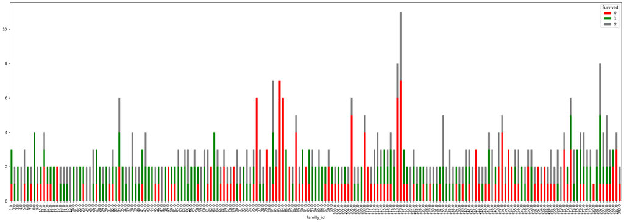

```python
pd.crosstab(df_full['Familly_id'], df_full['Survived']).drop([0]).plot(kind='bar', stacked=True, color=['r','g','grey'], figsize=(30,10))
plt.show()
```

#### Couple

```python
df_full.head(2)
```

|  | PassengerId | Survived | Pclass | Name | Sex | Age | SibSp | Parch | Ticket | Fare | Embarked | Title | FamilySize | Alone | Last_Name | Familly_id_x | Familly_id_y | Familly_id_z | Familly_id |
| --- | --- | --- | --- | --- | --- | --- | --- | --- | --- | --- | --- | --- | --- | --- | --- | --- | --- | --- | --- |
| 0 | 846 | 0 | 3 | Abbing, Mr. Anthony | male | 42.00 | 0 | 0 | C.A. 5547 | 7.55 | S | Mr | 1 | 1 | Abbing | nan | nan | nan | 0.00 |
| 1 | 1284 | 9 | 3 | Abbott, Master. Eugene Joseph | male | 13.00 | 0 | 2 | C.A. 2673 | 20.25 | S | Master | 3 | 0 | Abbott | 114.00 | nan | nan | 114.00 |

```python
df_full['group_size'] = df_full.groupby(['Familly_id']).PassengerId.transform('count')
df_full.loc[df_full['group_size']==790, 'group_size'] = 0
```

```python
d_sex = {'male':1, 'female' : 0}
df_full['Sex'] = df_full['Sex'].map(d_sex)
# df_full.loc[df_full['group_size']==2].groupby(['Familly_id']).Sex.sum()
```

```python
df_full['grp_cnt_male'] = df_full.groupby(['Familly_id']).Sex.transform('sum')
```

```python
df_full.head(2)
```

|  | PassengerId | Survived | Pclass | Name | Sex | Age | SibSp | Parch | Ticket | Fare | Embarked | Title | FamilySize | Alone | Last_Name | Familly_id_x | Familly_id_y | Familly_id_z | Familly_id | group_size | grp_cnt_male |
| --- | --- | --- | --- | --- | --- | --- | --- | --- | --- | --- | --- | --- | --- | --- | --- | --- | --- | --- | --- | --- | --- |
| 0 | 846 | 0 | 3 | Abbing, Mr. Anthony | 1 | 42.00 | 0 | 0 | C.A. 5547 | 7.55 | S | Mr | 1 | 1 | Abbing | nan | nan | nan | 0.00 | 0 | 596 |
| 1 | 1284 | 9 | 3 | Abbott, Master. Eugene Joseph | 1 | 13.00 | 0 | 2 | C.A. 2673 | 20.25 | S | Master | 3 | 0 | Abbott | 114.00 | nan | nan | 114.00 | 3 | 2 |

```python
df_full['Couple'] = 0
```

```python
df_full.loc[ (df_full['group_size'] == 2) & (df_full['grp_cnt_male'] == 1) & (df_full['SibSp'] == 1), 'Couple'] = 1
```

```python
couple = df_full.loc[df_full['Couple'] == 1 ]
```

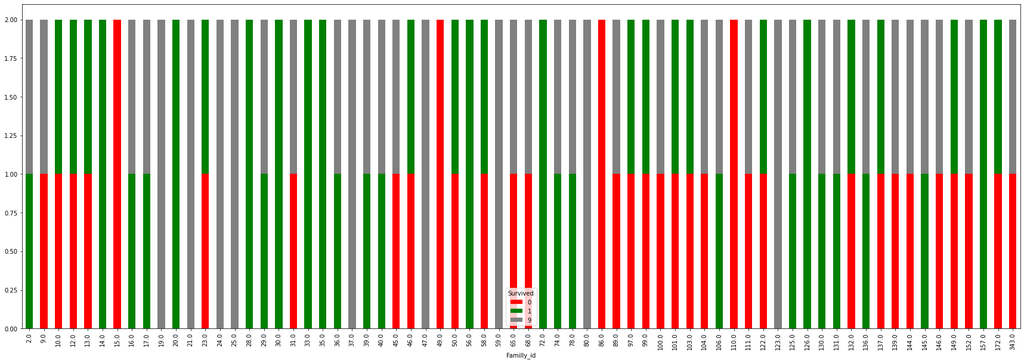

```python
pd.crosstab(couple['Familly_id'], couple['Survived']).plot(kind='bar', stacked=True, color=['r','g','grey'], figsize=(30,10))
plt.show()
```

### Data correlation

```python
# d_sex = {'male':1, 'female' : 0}
# for df in dfs:
#   df[1]['Sex'] = df[1]['Sex'].map(d_sex)
```

```python
# mask = np.triu(np.ones_like(df_train.corr(), dtype=bool))
```

```python
# plt.figure(figsize=(12,6))
# sns.heatmap(df_train.corr(),mask=mask ,annot = True, fmt = '.2f')
# plt.show()
```

## Fill NAn

#### Fare

We saw there is only one passenger with missing Fare value in test set.

Median Fare value of a male with a third class ticket and no family is a logical choice to fill the missing value.

```python
df_full.groupby(['Pclass','Sex' ,'Parch', 'SibSp']).Fare.median()[3][1][0][0]
```

```
7.8875
```

```python
med_fare = df_full.groupby(['Pclass','Sex' ,'Parch', 'SibSp']).Fare.median()[3][1][0][0]
# Filling the missing value in Fare with the median Fare of 3rd class alone passenger
df_full.loc[(df_full['Fare'].isnull()) & (df_full['Survived']==9),'Fare'] = med_fare
```

#### Age

We will use a model to predict missing Age

```python
df_full = df_full.sort_values(by='PassengerId').reset_index(drop=True)
df_full.head()
```

|  | PassengerId | Survived | Pclass | Name | Sex | Age | SibSp | Parch | Ticket | Fare | Embarked | Title | FamilySize | Alone | Last_Name | Familly_id_x | Familly_id_y | Familly_id_z | Familly_id | group_size | grp_cnt_male | Couple |
| --- | --- | --- | --- | --- | --- | --- | --- | --- | --- | --- | --- | --- | --- | --- | --- | --- | --- | --- | --- | --- | --- | --- |
| 0 | 1 | 0 | 3 | Braund, Mr. Owen Harris | 1 | 22.00 | 1 | 0 | A/5 21171 | 7.25 | S | Mr | 2 | 0 | Braund | nan | 154.00 | nan | 154.00 | 2 | 2 | 0 |
| 1 | 2 | 1 | 1 | Cumings, Mrs. John Bradley (Florence Briggs Th... | 0 | 38.00 | 1 | 0 | PC 17599 | 71.28 | C | Mrs | 2 | 0 | Cumings | 130.00 | nan | nan | 130.00 | 2 | 1 | 1 |
| 2 | 3 | 1 | 3 | Heikkinen, Miss. Laina | 0 | 26.00 | 0 | 0 | STON/O2. 3101282 | 7.92 | S | Miss | 1 | 1 | Heikkinen | nan | nan | nan | 0.00 | 0 | 596 | 0 |
| 3 | 4 | 1 | 1 | Futrelle, Mrs. Jacques Heath (Lily May Peel) | 0 | 35.00 | 1 | 0 | 113803 | 53.10 | S | Mrs | 2 | 0 | Futrelle | 13.00 | nan | nan | 13.00 | 2 | 1 | 1 |
| 4 | 5 | 0 | 3 | Allen, Mr. William Henry | 1 | 35.00 | 0 | 0 | 373450 | 8.05 | S | Mr | 1 | 1 | Allen | nan | nan | nan | 0.00 | 0 | 596 | 0 |

```python
df_train_test = df_full.copy()
df_train_test.drop(['Name', 'Last_Name', 'Ticket', 'Familly_id_x', 'Familly_id_y', 'Familly_id_z', 'FamilySize' ,'grp_cnt_male'], axis =1, inplace = True)
df_train_test
```

|  | PassengerId | Survived | Pclass | Sex | Age | SibSp | Parch | Fare | Embarked | Title | Alone | Familly_id | group_size | Couple |
| --- | --- | --- | --- | --- | --- | --- | --- | --- | --- | --- | --- | --- | --- | --- |
| 0 | 1 | 0 | 3 | 1 | 22.00 | 1 | 0 | 7.25 | S | Mr | 0 | 154.00 | 2 | 0 |
| 1 | 2 | 1 | 1 | 0 | 38.00 | 1 | 0 | 71.28 | C | Mrs | 0 | 130.00 | 2 | 1 |
| 2 | 3 | 1 | 3 | 0 | 26.00 | 0 | 0 | 7.92 | S | Miss | 1 | 0.00 | 0 | 0 |
| 3 | 4 | 1 | 1 | 0 | 35.00 | 1 | 0 | 53.10 | S | Mrs | 0 | 13.00 | 2 | 1 |
| 4 | 5 | 0 | 3 | 1 | 35.00 | 0 | 0 | 8.05 | S | Mr | 1 | 0.00 | 0 | 0 |
| ... | ... | ... | ... | ... | ... | ... | ... | ... | ... | ... | ... | ... | ... | ... |
| 1304 | 1305 | 9 | 3 | 1 | nan | 0 | 0 | 8.05 | S | Mr | 1 | 0.00 | 0 | 0 |
| 1305 | 1306 | 9 | 1 | 0 | 39.00 | 0 | 0 | 108.90 | C | High | 1 | 0.00 | 0 | 0 |
| 1306 | 1307 | 9 | 3 | 1 | 38.50 | 0 | 0 | 7.25 | S | Mr | 1 | 0.00 | 0 | 0 |
| 1307 | 1308 | 9 | 3 | 1 | nan | 0 | 0 | 8.05 | S | Mr | 1 | 0.00 | 0 | 0 |
| 1308 | 1309 | 9 | 3 | 1 | nan | 1 | 1 | 22.36 | C | Master | 0 | 64.00 | 3 | 0 |

1309 rows × 14 columns

### Encoding

Feature to encode:

- Sex (binary)
- Embarked (OHE)
- Title (OHE)

```python
# Sex
# d_sex = {'male':1, 'female' : 0}
# df_train_test['Sex'] = df_train_test['Sex'].map(d_sex)
```

```python
# Embarked, Title
df_train_test = pd.get_dummies(df_train_test, columns=['Embarked', 'Title'])
df_train_test.head()
```

|  | PassengerId | Survived | Pclass | Sex | Age | SibSp | Parch | Fare | Alone | Familly_id | group_size | Couple | Embarked_C | Embarked_Q | Embarked_S | Title_High | Title_Master | Title_Miss | Title_Mr | Title_Mrs |
| --- | --- | --- | --- | --- | --- | --- | --- | --- | --- | --- | --- | --- | --- | --- | --- | --- | --- | --- | --- | --- |
| 0 | 1 | 0 | 3 | 1 | 22.00 | 1 | 0 | 7.25 | 0 | 154.00 | 2 | 0 | 0 | 0 | 1 | 0 | 0 | 0 | 1 | 0 |
| 1 | 2 | 1 | 1 | 0 | 38.00 | 1 | 0 | 71.28 | 0 | 130.00 | 2 | 1 | 1 | 0 | 0 | 0 | 0 | 0 | 0 | 1 |
| 2 | 3 | 1 | 3 | 0 | 26.00 | 0 | 0 | 7.92 | 1 | 0.00 | 0 | 0 | 0 | 0 | 1 | 0 | 0 | 1 | 0 | 0 |
| 3 | 4 | 1 | 1 | 0 | 35.00 | 1 | 0 | 53.10 | 0 | 13.00 | 2 | 1 | 0 | 0 | 1 | 0 | 0 | 0 | 0 | 1 |
| 4 | 5 | 0 | 3 | 1 | 35.00 | 0 | 0 | 8.05 | 1 | 0.00 | 0 | 0 | 0 | 0 | 1 | 0 | 0 | 0 | 1 | 0 |

```python
col_to_add_after_training = ['Survived', 'Familly_id','PassengerId', 'Embarked_C', 'Embarked_Q', 'Embarked_S']
add_columns_train_test = df_train_test[col_to_add_after_training]
```

```python
# we drop survived bc of Nan and Familly_id
df_train_test.drop(col_to_add_after_training, axis=1,inplace=True)
df_train_test
```

|  | Pclass | Sex | Age | SibSp | Parch | Fare | Alone | group_size | Couple | Title_High | Title_Master | Title_Miss | Title_Mr | Title_Mrs |
| --- | --- | --- | --- | --- | --- | --- | --- | --- | --- | --- | --- | --- | --- | --- |
| 0 | 3 | 1 | 22.00 | 1 | 0 | 7.25 | 0 | 2 | 0 | 0 | 0 | 0 | 1 | 0 |
| 1 | 1 | 0 | 38.00 | 1 | 0 | 71.28 | 0 | 2 | 1 | 0 | 0 | 0 | 0 | 1 |
| 2 | 3 | 0 | 26.00 | 0 | 0 | 7.92 | 1 | 0 | 0 | 0 | 0 | 1 | 0 | 0 |
| 3 | 1 | 0 | 35.00 | 1 | 0 | 53.10 | 0 | 2 | 1 | 0 | 0 | 0 | 0 | 1 |
| 4 | 3 | 1 | 35.00 | 0 | 0 | 8.05 | 1 | 0 | 0 | 0 | 0 | 0 | 1 | 0 |
| ... | ... | ... | ... | ... | ... | ... | ... | ... | ... | ... | ... | ... | ... | ... |
| 1304 | 3 | 1 | nan | 0 | 0 | 8.05 | 1 | 0 | 0 | 0 | 0 | 0 | 1 | 0 |
| 1305 | 1 | 0 | 39.00 | 0 | 0 | 108.90 | 1 | 0 | 0 | 1 | 0 | 0 | 0 | 0 |
| 1306 | 3 | 1 | 38.50 | 0 | 0 | 7.25 | 1 | 0 | 0 | 0 | 0 | 0 | 1 | 0 |
| 1307 | 3 | 1 | nan | 0 | 0 | 8.05 | 1 | 0 | 0 | 0 | 0 | 0 | 1 | 0 |
| 1308 | 3 | 1 | nan | 1 | 1 | 22.36 | 0 | 3 | 0 | 0 | 1 | 0 | 0 | 0 |

1309 rows × 14 columns

```python
df_age_null = df_train_test.loc[df_train_test.Age.isnull()]
```

```python
df_age_notnull = df_train_test.loc[df_train_test.Age.notnull()]

X = df_age_notnull.drop('Age', axis=1)
y = df_age_notnull['Age']
```

```python
X_age_train, X_age_test, y_age_train, y_age_test = train_test_split(X, y, random_state=42)
```

```python
reg = LazyRegressor(ignore_warnings=False, custom_metric=None)
models, predictions = reg.fit(X_age_train, X_age_test, y_age_train, y_age_test)
print(models)
```

```
                               Adjusted R-Squared  R-Squared    RMSE  \
Model
GradientBoostingRegressor                    0.42       0.45    9.76
MLPRegressor                                 0.40       0.43    9.88
SVR                                          0.39       0.42   10.02
HistGradientBoostingRegressor                0.38       0.41   10.06
LGBMRegressor                                0.37       0.40   10.14
LinearSVR                                    0.36       0.39   10.25
NuSVR                                        0.36       0.39   10.27
Lasso                                        0.35       0.38   10.32
LarsCV                                       0.35       0.38   10.35
LassoLarsIC                                  0.34       0.38   10.38
PoissonRegressor                             0.34       0.37   10.40
HuberRegressor                               0.34       0.37   10.42
SGDRegressor                                 0.34       0.37   10.44
BayesianRidge                                0.33       0.37   10.44
ElasticNet                                   0.33       0.37   10.44
ElasticNetCV                                 0.33       0.36   10.47
GammaRegressor                               0.33       0.36   10.49
LassoCV                                      0.33       0.36   10.51
LassoLarsCV                                  0.33       0.36   10.51
Ridge                                        0.32       0.36   10.52
XGBRegressor                                 0.32       0.36   10.52
OrthogonalMatchingPursuitCV                  0.32       0.36   10.53
RidgeCV                                      0.32       0.36   10.54
Lars                                         0.32       0.35   10.56
GeneralizedLinearRegressor                   0.31       0.35   10.61
TweedieRegressor                             0.31       0.35   10.61
RandomForestRegressor                        0.31       0.35   10.62
LinearRegression                             0.31       0.35   10.62
TransformedTargetRegressor                   0.31       0.35   10.62
BaggingRegressor                             0.29       0.33   10.76
KNeighborsRegressor                          0.29       0.33   10.77
AdaBoostRegressor                            0.28       0.32   10.85
ExtraTreesRegressor                          0.25       0.29   11.06
RANSACRegressor                              0.21       0.25   11.40
ExtraTreeRegressor                           0.20       0.24   11.43
DecisionTreeRegressor                        0.11       0.15   12.10
OrthogonalMatchingPursuit                    0.11       0.15   12.10
PassiveAggressiveRegressor                   0.00       0.05   12.78
```

[output cut: 34 more lines]

```
LinearRegression                     0.03
TransformedTargetRegressor           0.02
BaggingRegressor                     0.05
KNeighborsRegressor                  0.03
AdaBoostRegressor                    0.05
ExtraTreesRegressor                  0.27
RANSACRegressor                      0.11
ExtraTreeRegressor                   0.03
DecisionTreeRegressor                0.03
OrthogonalMatchingPursuit            0.02
PassiveAggressiveRegressor           0.03
DummyRegressor                       0.02
LassoLars                            0.05
KernelRidge                          0.05
GaussianProcessRegressor             0.15
```

```python
reg = GradientBoostingRegressor(random_state=42)
reg.fit(X, y)
y_pred_age = reg.predict(df_age_null.drop('Age', axis=1))
```

```python
sorted(list(zip(X.columns,reg.feature_importances_)), key=lambda x : x[1], reverse = True)
```

```
[('Pclass', 0.2875237075556218),
 ('Title_Master', 0.22308304933036294),
 ('Title_Miss', 0.18876610581152578),
 ('Fare', 0.12578727577969293),
 ('Parch', 0.07597726791742207),
 ('group_size', 0.031715938077858045),
 ('SibSp', 0.020654143919620067),
 ('Title_Mrs', 0.019772061769482752),
 ('Title_High', 0.011331929875531917),
 ('Couple', 0.011230777637127936),
 ('Title_Mr', 0.0031612664439292478),
 ('Sex', 0.0008108349957762699),
 ('Alone', 0.000185640886048369)]
```

```python
df_age_null.Age = y_pred_age
```

```python
df_full = pd.concat([df_age_notnull,df_age_null], axis = 0).sort_index()
df_full = pd.concat([df_full,add_columns_train_test], axis=1)
```

```python
# df_train = df_full.iloc[:len(df_train)]
# df_test = df_full.iloc[len(df_train):]
```

```python
df_full
```

|  | Pclass | Sex | Age | SibSp | Parch | Fare | Alone | group_size | Couple | Title_High | Title_Master | Title_Miss | Title_Mr | Title_Mrs | Survived | Familly_id | PassengerId | Embarked_C | Embarked_Q | Embarked_S |
| --- | --- | --- | --- | --- | --- | --- | --- | --- | --- | --- | --- | --- | --- | --- | --- | --- | --- | --- | --- | --- |
| 0 | 3 | 1 | 22.00 | 1 | 0 | 7.25 | 0 | 2 | 0 | 0 | 0 | 0 | 1 | 0 | 0 | 154.00 | 1 | 0 | 0 | 1 |
| 1 | 1 | 0 | 38.00 | 1 | 0 | 71.28 | 0 | 2 | 1 | 0 | 0 | 0 | 0 | 1 | 1 | 130.00 | 2 | 1 | 0 | 0 |
| 2 | 3 | 0 | 26.00 | 0 | 0 | 7.92 | 1 | 0 | 0 | 0 | 0 | 1 | 0 | 0 | 1 | 0.00 | 3 | 0 | 0 | 1 |
| 3 | 1 | 0 | 35.00 | 1 | 0 | 53.10 | 0 | 2 | 1 | 0 | 0 | 0 | 0 | 1 | 1 | 13.00 | 4 | 0 | 0 | 1 |
| 4 | 3 | 1 | 35.00 | 0 | 0 | 8.05 | 1 | 0 | 0 | 0 | 0 | 0 | 1 | 0 | 0 | 0.00 | 5 | 0 | 0 | 1 |
| ... | ... | ... | ... | ... | ... | ... | ... | ... | ... | ... | ... | ... | ... | ... | ... | ... | ... | ... | ... | ... |
| 1304 | 3 | 1 | 28.56 | 0 | 0 | 8.05 | 1 | 0 | 0 | 0 | 0 | 0 | 1 | 0 | 9 | 0.00 | 1305 | 0 | 0 | 1 |
| 1305 | 1 | 0 | 39.00 | 0 | 0 | 108.90 | 1 | 0 | 0 | 1 | 0 | 0 | 0 | 0 | 9 | 0.00 | 1306 | 1 | 0 | 0 |
| 1306 | 3 | 1 | 38.50 | 0 | 0 | 7.25 | 1 | 0 | 0 | 0 | 0 | 0 | 1 | 0 | 9 | 0.00 | 1307 | 0 | 0 | 1 |
| 1307 | 3 | 1 | 28.56 | 0 | 0 | 8.05 | 1 | 0 | 0 | 0 | 0 | 0 | 1 | 0 | 9 | 0.00 | 1308 | 0 | 0 | 1 |
| 1308 | 3 | 1 | 6.78 | 1 | 1 | 22.36 | 0 | 3 | 0 | 0 | 1 | 0 | 0 | 0 | 9 | 64.00 | 1309 | 1 | 0 | 0 |

1309 rows × 20 columns

## Feature engineering 2

#### Family with children

```python
df_full['Familly_wt_chld'] = df_full.groupby(['Familly_id']).Age.transform('min')
df_full['Familly_wt_chld'].loc[df_full['Familly_wt_chld']<17] = 1
df_full['Familly_wt_chld'].loc[df_full['Familly_wt_chld']>=17] = 0
df_full.loc[(df_full['Alone'] == 1), 'Familly_wt_chld'] = 0
df_full.loc[(df_full['Couple'] == 1), 'Familly_wt_chld'] = 0
```

```python
df_full.head()
```

|  | Pclass | Sex | Age | SibSp | Parch | Fare | Alone | group_size | Couple | Title_High | Title_Master | Title_Miss | Title_Mr | Title_Mrs | Survived | Familly_id | PassengerId | Embarked_C | Embarked_Q | Embarked_S | Familly_wt_chld |
| --- | --- | --- | --- | --- | --- | --- | --- | --- | --- | --- | --- | --- | --- | --- | --- | --- | --- | --- | --- | --- | --- |
| 0 | 3 | 1 | 22.00 | 1 | 0 | 7.25 | 0 | 2 | 0 | 0 | 0 | 0 | 1 | 0 | 0 | 154.00 | 1 | 0 | 0 | 1 | 0.00 |
| 1 | 1 | 0 | 38.00 | 1 | 0 | 71.28 | 0 | 2 | 1 | 0 | 0 | 0 | 0 | 1 | 1 | 130.00 | 2 | 1 | 0 | 0 | 0.00 |
| 2 | 3 | 0 | 26.00 | 0 | 0 | 7.92 | 1 | 0 | 0 | 0 | 0 | 1 | 0 | 0 | 1 | 0.00 | 3 | 0 | 0 | 1 | 0.00 |
| 3 | 1 | 0 | 35.00 | 1 | 0 | 53.10 | 0 | 2 | 1 | 0 | 0 | 0 | 0 | 1 | 1 | 13.00 | 4 | 0 | 0 | 1 | 0.00 |
| 4 | 3 | 1 | 35.00 | 0 | 0 | 8.05 | 1 | 0 | 0 | 0 | 0 | 0 | 1 | 0 | 0 | 0.00 | 5 | 0 | 0 | 1 | 0.00 |

```python
chld = df_full.loc[df_full['Familly_wt_chld'] == 1 ]
```

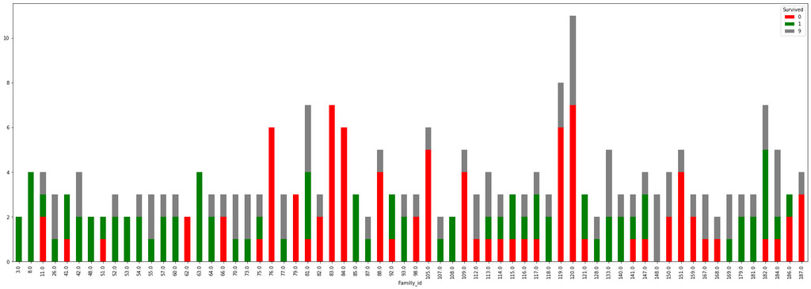

```python
pd.crosstab(chld['Familly_id'], chld['Survived']).plot(kind='bar', stacked=True, color=['r','g','grey'], figsize=(30,10))
plt.show()
```

Big familly (up to 4 people) => more likely to all died maybe they want to stay together

Small familly tend to all survived or just the men died

#### Connected survival

```python
df_full['Connected_Survival'] = df_full.groupby(['Familly_id'])['Survived'].transform('median')
```

```python
df_full.loc[df_full['Alone']==1, 'Connected_Survival'] = 0.5
df_full.loc[df_full['Connected_Survival']== 5 , 'Connected_Survival'] = 0.5
df_full.loc[df_full['Connected_Survival']== 4.5, 'Connected_Survival'] = 0.5
df_full.loc[df_full['Connected_Survival']== 9, 'Connected_Survival'] = 0.5
```

```python
df_full['Connected_Survival'].value_counts()
```

```
0.50    1027
1.00     170
0.00     112
Name: Connected_Survival, dtype: int64
```

```python
df_full.head()
```

|  | Pclass | Sex | Age | SibSp | Parch | Fare | Alone | group_size | Couple | Title_High | Title_Master | Title_Miss | Title_Mr | Title_Mrs | Survived | Familly_id | PassengerId | Embarked_C | Embarked_Q | Embarked_S | Familly_wt_chld | Connected_Survival |
| --- | --- | --- | --- | --- | --- | --- | --- | --- | --- | --- | --- | --- | --- | --- | --- | --- | --- | --- | --- | --- | --- | --- |
| 0 | 3 | 1 | 22.00 | 1 | 0 | 7.25 | 0 | 2 | 0 | 0 | 0 | 0 | 1 | 0 | 0 | 154.00 | 1 | 0 | 0 | 1 | 0.00 | 0.00 |
| 1 | 1 | 0 | 38.00 | 1 | 0 | 71.28 | 0 | 2 | 1 | 0 | 0 | 0 | 0 | 1 | 1 | 130.00 | 2 | 1 | 0 | 0 | 0.00 | 0.50 |
| 2 | 3 | 0 | 26.00 | 0 | 0 | 7.92 | 1 | 0 | 0 | 0 | 0 | 1 | 0 | 0 | 1 | 0.00 | 3 | 0 | 0 | 1 | 0.00 | 0.50 |
| 3 | 1 | 0 | 35.00 | 1 | 0 | 53.10 | 0 | 2 | 1 | 0 | 0 | 0 | 0 | 1 | 1 | 13.00 | 4 | 0 | 0 | 1 | 0.00 | 0.50 |
| 4 | 3 | 1 | 35.00 | 0 | 0 | 8.05 | 1 | 0 | 0 | 0 | 0 | 0 | 1 | 0 | 0 | 0.00 | 5 | 0 | 0 | 1 | 0.00 | 0.50 |

```python
df_full.iloc[:len(df_train)].drop(['Familly_id', 'PassengerId'], axis = 1).head()
```

|  | Pclass | Sex | Age | SibSp | Parch | Fare | Alone | group_size | Couple | Title_High | Title_Master | Title_Miss | Title_Mr | Title_Mrs | Survived | Embarked_C | Embarked_Q | Embarked_S | Familly_wt_chld | Connected_Survival |
| --- | --- | --- | --- | --- | --- | --- | --- | --- | --- | --- | --- | --- | --- | --- | --- | --- | --- | --- | --- | --- |
| 0 | 3 | 1 | 22.00 | 1 | 0 | 7.25 | 0 | 2 | 0 | 0 | 0 | 0 | 1 | 0 | 0 | 0 | 0 | 1 | 0.00 | 0.00 |
| 1 | 1 | 0 | 38.00 | 1 | 0 | 71.28 | 0 | 2 | 1 | 0 | 0 | 0 | 0 | 1 | 1 | 1 | 0 | 0 | 0.00 | 0.50 |
| 2 | 3 | 0 | 26.00 | 0 | 0 | 7.92 | 1 | 0 | 0 | 0 | 0 | 1 | 0 | 0 | 1 | 0 | 0 | 1 | 0.00 | 0.50 |
| 3 | 1 | 0 | 35.00 | 1 | 0 | 53.10 | 0 | 2 | 1 | 0 | 0 | 0 | 0 | 1 | 1 | 0 | 0 | 1 | 0.00 | 0.50 |
| 4 | 3 | 1 | 35.00 | 0 | 0 | 8.05 | 1 | 0 | 0 | 0 | 0 | 0 | 1 | 0 | 0 | 0 | 0 | 1 | 0.00 | 0.50 |

```python
# df_train = df_full.iloc[:len(df_train)].drop(['Familly_id', 'PassengerId', 'SibSp', 'Parch', 'Embarked_C', 'Embarked_Q', 'Embarked_S'], axis = 1)
# df_test = df_full.iloc[len(df_train):].drop(['Familly_id', 'PassengerId', 'SibSp', 'Parch', 'Embarked_C', 'Embarked_Q', 'Embarked_S'], axis = 1)

df_train = df_full.iloc[:len(df_train)].drop(['Familly_id', 'PassengerId'], axis = 1)
df_test = df_full.iloc[len(df_train):].drop(['Familly_id', 'PassengerId'], axis = 1)
```

## Modeling

### Preprocessing

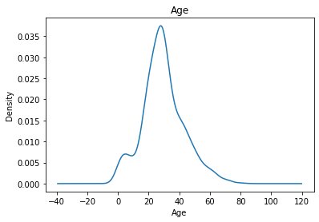

```python
df_train.Age.plot(kind='kde')
plt.title('Age')
plt.xlabel('Age')
plt.show()
```

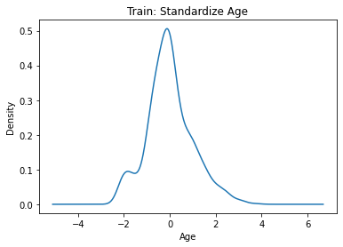

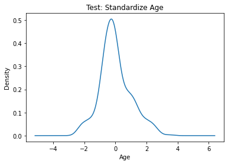

```python
scaler = StandardScaler()

df_train['Age'] = scaler.fit_transform(df_train[['Age']])
df_test['Age'] = scaler.fit_transform(df_test[['Age']])


df_train['Age'].plot(kind='kde')
plt.title('Train: Standardize Age')
plt.xlabel('Age')
plt.show()


df_test['Age'].plot(kind='kde')
plt.title('Test: Standardize Age')
plt.xlabel('Age')
plt.show()
```

[figure not shown]

```python
df_train.Fare.plot(kind='kde')
plt.title('Standardize log Fare')
plt.xlabel('Fare')
plt.show()
```

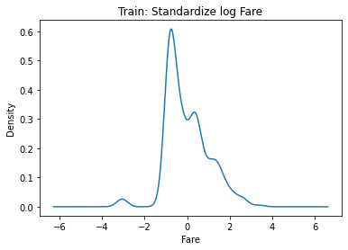

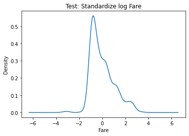

```python
transformer = FunctionTransformer(np.log1p, validate=True)

df_train['Fare'] = scaler.fit_transform(transformer.transform(df_train[['Fare']]))
df_test['Fare'] = scaler.fit_transform(transformer.transform(df_test[['Fare']]))

df_train['Fare'].plot(kind='kde')
plt.title('Train: Standardize log Fare')
plt.xlabel('Fare')
plt.show()


df_test['Fare'].plot(kind='kde')
plt.title('Test: Standardize log Fare')
plt.xlabel('Fare')
plt.show()
```

```python
df_train
```

|  | Pclass | Sex | Age | SibSp | Parch | Fare | Alone | group_size | Couple | Title_High | Title_Master | Title_Miss | Title_Mr | Title_Mrs | Survived | Embarked_C | Embarked_Q | Embarked_S | Familly_wt_chld | Connected_Survival |
| --- | --- | --- | --- | --- | --- | --- | --- | --- | --- | --- | --- | --- | --- | --- | --- | --- | --- | --- | --- | --- |
| 0 | 3 | 1 | -0.56 | 1 | 0 | -0.88 | 0 | 2 | 0 | 0 | 0 | 0 | 1 | 0 | 0 | 0 | 0 | 1 | 0.00 | 0.00 |
| 1 | 1 | 0 | 0.63 | 1 | 0 | 1.36 | 0 | 2 | 1 | 0 | 0 | 0 | 0 | 1 | 1 | 1 | 0 | 0 | 0.00 | 0.50 |
| 2 | 3 | 0 | -0.26 | 0 | 0 | -0.80 | 1 | 0 | 0 | 0 | 0 | 1 | 0 | 0 | 1 | 0 | 0 | 1 | 0.00 | 0.50 |
| 3 | 1 | 0 | 0.40 | 1 | 0 | 1.06 | 0 | 2 | 1 | 0 | 0 | 0 | 0 | 1 | 1 | 0 | 0 | 1 | 0.00 | 0.50 |
| 4 | 3 | 1 | 0.40 | 0 | 0 | -0.78 | 1 | 0 | 0 | 0 | 0 | 0 | 1 | 0 | 0 | 0 | 0 | 1 | 0.00 | 0.50 |
| ... | ... | ... | ... | ... | ... | ... | ... | ... | ... | ... | ... | ... | ... | ... | ... | ... | ... | ... | ... | ... |
| 886 | 2 | 1 | -0.19 | 0 | 0 | -0.33 | 1 | 0 | 0 | 1 | 0 | 0 | 0 | 0 | 0 | 0 | 0 | 1 | 0.00 | 0.50 |
| 887 | 1 | 0 | -0.78 | 0 | 0 | 0.49 | 1 | 0 | 0 | 0 | 0 | 1 | 0 | 0 | 1 | 0 | 0 | 1 | 0.00 | 0.50 |
| 888 | 3 | 0 | -1.60 | 1 | 2 | 0.24 | 0 | 4 | 0 | 0 | 0 | 1 | 0 | 0 | 0 | 0 | 0 | 1 | 1.00 | 0.50 |
| 889 | 1 | 1 | -0.26 | 0 | 0 | 0.49 | 1 | 0 | 0 | 0 | 0 | 0 | 1 | 0 | 1 | 1 | 0 | 0 | 0.00 | 0.50 |
| 890 | 3 | 1 | 0.18 | 0 | 0 | -0.82 | 1 | 0 | 0 | 0 | 0 | 0 | 1 | 0 | 0 | 0 | 1 | 0 | 0.00 | 0.50 |

891 rows × 20 columns

### Feature selection

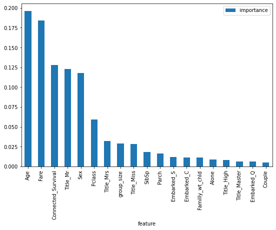

```python
X = df_train.drop('Survived', axis=1)
y = df_train['Survived']
X_train, X_test, y_train, y_test = train_test_split(X, y, random_state=42)

model = RandomForestClassifier(n_estimators=200, random_state=2)


model.fit(X_train,y_train)
importance = pd.DataFrame({'feature':X_train.columns, 'importance': np.round(model.feature_importances_,3)}).sort_values('importance', ascending=False).set_index('feature')
importance.plot(kind='bar', rot=90, figsize=(9,6))
plt.show()
```

```python
importance.index
```

```
Index(['Age', 'Fare', 'Connected_Survival', 'Title_Mr', 'Sex', 'Pclass',
       'Title_Mrs', 'group_size', 'Title_Miss', 'SibSp', 'Parch', 'Embarked_S',
       'Embarked_C', 'Familly_wt_chld', 'Alone', 'Title_High', 'Title_Master',
       'Embarked_Q', 'Couple'],
      dtype='object', name='feature')
```

```python
selected_cols = ['Age', 'Fare', 'Connected_Survival', 'Title_Mr', 'Sex', 'Pclass',
       'Title_Mrs', 'group_size', 'Title_Miss', 'Title_High', 'Title_Master','Survived']
```

```python
df_train = df_train[selected_cols]
df_test = df_test[selected_cols]
```

### Model selection

```python
X = df_train.drop('Survived', axis=1)
y = df_train['Survived']
X_train, X_test, y_train, y_test = train_test_split(X, y, random_state=42)
```

```python
# X_train, X_test, y_train, y_test = train_test_split(X, y, random_state=42)
```

```python
clf = LazyClassifier(ignore_warnings=False, custom_metric=None)
models, predictions = clf.fit(X_train, X_test, y_train, y_test)
print(models)
```

```
CategoricalNB model failed to execute
Negative values in data passed to CategoricalNB (input X)
```

```
StackingClassifier model failed to execute
__init__() missing 1 required positional argument: 'estimators'
                               Accuracy  Balanced Accuracy  ROC AUC  F1 Score  \
Model
LabelPropagation                   0.88               0.87     0.87      0.88
LabelSpreading                     0.88               0.87     0.87      0.88
LGBMClassifier                     0.86               0.86     0.86      0.86
RidgeClassifierCV                  0.87               0.86     0.86      0.87
RidgeClassifier                    0.87               0.86     0.86      0.87
LogisticRegression                 0.87               0.86     0.86      0.87
LinearDiscriminantAnalysis         0.87               0.86     0.86      0.87
LinearSVC                          0.87               0.86     0.86      0.87
CalibratedClassifierCV             0.87               0.86     0.86      0.87
SGDClassifier                      0.87               0.85     0.85      0.86
ExtraTreesClassifier               0.85               0.84     0.84      0.85
RandomForestClassifier             0.85               0.84     0.84      0.85
SVC                                0.86               0.84     0.84      0.86
NuSVC                              0.86               0.84     0.84      0.86
AdaBoostClassifier                 0.85               0.84     0.84      0.85
XGBClassifier                      0.83               0.83     0.83      0.83
PassiveAggressiveClassifier        0.83               0.83     0.83      0.83
DecisionTreeClassifier             0.83               0.83     0.83      0.83
KNeighborsClassifier               0.83               0.82     0.82      0.83
BaggingClassifier                  0.83               0.82     0.82      0.83
ExtraTreeClassifier                0.82               0.82     0.82      0.82
BernoulliNB                        0.81               0.81     0.81      0.81
NearestCentroid                    0.80               0.80     0.80      0.80
GaussianNB                         0.79               0.79     0.79      0.79
Perceptron                         0.82               0.78     0.78      0.81
QuadraticDiscriminantAnalysis      0.61               0.51     0.51      0.46
DummyClassifier                    0.51               0.49     0.49      0.51

                               Time Taken
Model
LabelPropagation                     0.06
LabelSpreading                       0.07
LGBMClassifier                       0.08
RidgeClassifierCV                    0.02
RidgeClassifier                      0.03
LogisticRegression                   0.03
LinearDiscriminantAnalysis           0.03
LinearSVC                            0.07
CalibratedClassifierCV               0.17
SGDClassifier                        0.02
ExtraTreesClassifier                 0.19
RandomForestClassifier               0.23
SVC                                  0.03
NuSVC                                0.04
AdaBoostClassifier                   0.13
XGBClassifier                        0.10
PassiveAggressiveClassifier          0.02
DecisionTreeClassifier               0.02
KNeighborsClassifier                 0.03
BaggingClassifier                    0.05
ExtraTreeClassifier                  0.02
BernoulliNB                          0.02
NearestCentroid                      0.02
GaussianNB                           0.02
Perceptron                           0.02
QuadraticDiscriminantAnalysis        0.02
DummyClassifier                      0.02
```

### Model tuning: Grid search

```python
def grid_test(model_name, model, parameters, X_train=X_train, X_test=X_test, y_train=y_train, y_test=y_test ):

  model = GridSearchCV(
    model,
    parameters,
    cv=5,
    scoring='accuracy',
)

  model.fit(X_train, y_train)
  # y_pred = model.predict(X_test)

  # Mean cross-validated score of the best_estimator
  print(model_name, ': ', model.best_score_, '\n')
  # print(classification_report(y_test, y_pred),'\n')


  # return model_name, round(accuracy_score(y_test, y_pred)*100, 2), model.best_estimator_
  return model_name, model.best_score_, model.best_estimator_
```

```python
# good
lgbm_param = {
    'n_estimators': [5, 10, 15, 25, 50, 100, 125, 150],
    'learning_rate': [0.01, 0.05, 0.1],
    'num_leaves': [7, 15, 31],
}

# good
log_reg_param = {
    "penalty": ["l1", "l2"],

}

# good
xgb_param = {
    'max_depth': [3, 5, 7, 9],
    'n_estimators': [5, 10, 15, 20, 25, 50, 100],
    'learning_rate': [0.01, 0.05, 0.1]
}

# good
ada_param = {
    'n_estimators': [70, 100, 150, 200, 250,300, 400],
    'learning_rate': [0.01, 0.05, 0.1]
}

# good
svc_param = {
    "C": [0.001, 0.01, 0.1, 0.5, 1.],
    "kernel": ["linear", "poly", "rbf", "sigmoid"]
}

# good
knn_param = {
    'n_neighbors':[5, 10, 15, 20, 25],
    "weights": ["uniform", "distance"]
}

# good
rf_param = {
    "n_estimators": [5, 10, 15, 20, 25],
    "max_depth": [3, 5, 7, 9, 11, 13]
}

# good
d_tree_param =  {
    "max_depth": [3, 5, 7, 9, 11, 13]
}
```

```python
# lgbm = LGBMClassifier(random_state= 42)
log_reg = LogisticRegression(random_state= 42)
xgb = xgboost.XGBClassifier(random_state=42)
ada = AdaBoostClassifier(random_state=42)
svc = SVC(random_state=42)
knn = KNeighborsClassifier()
rf = RandomForestClassifier(random_state=42)
d_tree =  DecisionTreeClassifier(random_state=42)

models = [('LogisticRegression',log_reg, log_reg_param), ('XGBClassifier',xgb, xgb_param),
          ('AdaBoostClassifier',ada, ada_param), ('SVC',svc, svc_param), ('KNeighborsClassifier',knn, knn_param),
          ('RandomForestClassifier',rf, rf_param), ('Decision Tree',d_tree, d_tree_param) ]
```

```python
acc_dic={}
model_dic={}


for model in models:
  name,acc, best_model = grid_test(model[0],model[1],model[2])
  acc_dic[name] = acc
  model_dic[name] = best_model
```

```
LogisticRegression :  0.8622825721018966

XGBClassifier :  0.8623274604421501

AdaBoostClassifier :  0.8637975535854562

SVC :  0.8592974974750309

KNeighborsClassifier :  0.8308495118392998

RandomForestClassifier :  0.8682976096958814

Decision Tree :  0.8592862753899675
```

```python
pd.DataFrame.from_dict(acc_dic, orient='index', columns=['Mean CV Accuracy']).sort_values(by='Mean CV Accuracy', ascending=False)
```

|  | Mean CV Accuracy |
| --- | --- |
| RandomForestClassifier | 0.87 |
| AdaBoostClassifier | 0.86 |
| XGBClassifier | 0.86 |
| LogisticRegression | 0.86 |
| SVC | 0.86 |
| Decision Tree | 0.86 |
| KNeighborsClassifier | 0.83 |

```python
# param_dic
model_dic
```

```
{'AdaBoostClassifier': AdaBoostClassifier(learning_rate=0.05, n_estimators=150, random_state=42),
 'Decision Tree': DecisionTreeClassifier(max_depth=3, random_state=42),
 'KNeighborsClassifier': KNeighborsClassifier(n_neighbors=25),
 'LogisticRegression': LogisticRegression(random_state=42),
 'RandomForestClassifier': RandomForestClassifier(max_depth=11, n_estimators=15, random_state=42),
 'SVC': SVC(C=0.5, kernel='linear', random_state=42),
 'XGBClassifier': XGBClassifier(base_score=0.5, booster='gbtree', colsample_bylevel=1,
               colsample_bynode=1, colsample_bytree=1, gamma=0, gpu_id=-1,
               importance_type='gain', interaction_constraints='',
               learning_rate=0.05, max_delta_step=0, max_depth=3,
               min_child_weight=1, missing=nan, monotone_constraints='()',
               n_estimators=100, n_jobs=0, num_parallel_tree=1, random_state=42,
               reg_alpha=0, reg_lambda=1, scale_pos_weight=1, subsample=1,
               tree_method='exact', validate_parameters=1, verbosity=None)}
```

```python
# del model_dic['KNeighborsClassifier']
```

```python
merge_dic={}

for name in model_dic:
  clf = model_dic[name]
  clf.fit(X, y)
  merge_dic[name] = clf.predict(df_test.drop('Survived', axis =1)).astype(int)
  try:
    print(sorted(list(zip(X.columns, clf.feature_importances_)), key= lambda x: x[1], reverse =True))
  except:
    pass
```

[output not shown]

```python
df_pred = pd.DataFrame(merge_dic)
df_pred.head()
```

|  | LogisticRegression | XGBClassifier | AdaBoostClassifier | SVC | KNeighborsClassifier | RandomForestClassifier | Decision Tree |
| --- | --- | --- | --- | --- | --- | --- | --- |
| 0 | 0 | 0 | 0 | 0 | 0 | 0 | 0 |
| 1 | 0 | 1 | 1 | 1 | 0 | 1 | 1 |
| 2 | 0 | 0 | 0 | 0 | 0 | 0 | 0 |
| 3 | 0 | 0 | 0 | 0 | 0 | 0 | 0 |
| 4 | 1 | 1 | 1 | 1 | 1 | 1 | 1 |

```python
# np.round(df_pred.apply(sum, axis=1) / df_pred.shape[1]).astype(int)
```

```python
# y_pred = np.round(df_pred.apply(sum, axis=1) / df_pred.shape[1]).astype(int)

# submission = pd.concat([pd.Series(df_test.index+1, name='PassengerId'), pd.Series(y_pred, name='Survived')], axis=1)

# submission.to_csv('new_submission.csv', index=False)
```

```python
# top 6%
y_pred = df_pred['RandomForestClassifier']

submission = pd.concat([pd.Series(df_test.index+1, name='PassengerId'), pd.Series(y_pred, name='Survived')], axis=1)

submission.to_csv('RandomForestClassifier5.csv', index=False)
```